# Mieten in Deutschland

Worin liegen Probleme und Schwierigkeiten im deutschen Mietmarkt

# Motivation

Die Mietpreise in Deutschland spielen eine wichtige Rolle für eine Vielzahl der deutschen Bevölkerung, doch nicht alle Gemeinden sind gleichermaßen von hohen Mieten betroffen. Faktoren wie die Lage einer Stadt, das Angebot an Wohnraum, das Alter der Gebäude oder der Familienstand der Bewohner beeinflussen die Höhe der Mieten. Dies werden Sie in diesem Projekt anhand von Zensus-Daten auf Gemeindeebene für das Jahr 2022 genau untersuchen. Besonders interessant ist dabei, wie sich Mietpreise nicht nur zwischen verschiedenen Städten, sondern auch innerhalb einer Stadt unterscheiden. Sie werden feststellen, dass die Ursachen für diese Mietunterschiede komplex und vielschichtig sind. Ihre Aufgabe ist es, durch fundierte Analysen herauszuarbeiten, welche Faktoren den größten Einfluss auf die Mietentwicklung haben. Auf Basis dieser Erkenntnisse könnten Sie Handlungsempfehlungen geben, die Politik und Stadtplaner nutzen können, um die Mietpreisentwicklung besser zu steuern und Wohnraum gerechter zu gestalten.

# Datengrundlage

In diesem Projekt werden Sie mit mehreren unterschiedlichen Datensätzen arbeiten. Zum Einen werden Sie Zensusdaten aus dem Jahr 2022 zur Demografie genauer betrachten. Zum Anderen werden Sie Daten zur Wohnungszählung in deutschen Gemeinden und Städten untersuchen. Schließlich benötigen Sie die dazugehörigen Kartendaten, um die Informationen später anschaulich visualisieren zu können. Dort werden Sie die Details der Karten einlesen und darüber hinaus Zahlen zu Mieten selbstständig herunterladen und importieren.

## Einlesen

Mittlerweile wohnen knapp 54% der Menschen in Deutschland zur Miete (Stand 2022). Somit ist Deutschland das Mieterland Nummer 1 in Europa. Im Vergleich dazu haben Länder wie Frankreich (36,6%), Italien (25,7%) oder Spanien (24%) einen deutlich geringeren Anteil an Mietern. Für die Politik ist es besonders interessant zu erfahren, wie sich nun die Mieten in den unterschiedlichen Gemeinden in Deutschland verteilen und ob es Regionen gibt, wo es besonders schwer wird eine neue Wohnung zu finden. Um dies zu beleuchten, sollen Sie nun die nachfolgenden Datensätze genauer analysieren.

1. Lesen Sie den Datensatz `Demografie_Zensus.csv` ein und speichern diesen als `demografie`. Der Datensatz `demografie` enthält für jede Gemeinde mehrere Beobachtungen. Dies liegt daran, dass für jede Altersgruppe der Personen eine eigene Beobachtung vorliegt. Allerdings ist der Datensatz im long-Format, d.h. nicht tidy und damit nicht so, wie Sie ihn für die weitere Datenanalyse benötigen. Nun soll der Datensatz so abgeändert werden, dass jede Gemeinde nur noch eine Beobachtung darstellt. Passen Sie den Datensatz so an, dass Sie für jede `Altersgruppe` eine eigene Spalte erstellen und dort jeweils die Anzahl der Menschen, die Sie der Spalte `Anzahl pro Altersgruppe` entnehmen können, eingetragen wird.

Darüberhinaus sollen Sie nun einen weiteren Datensatz `Wohnungen_Zensus.csv` einlesen, welcher Informationen zu den einzelnen Wohnungen in den Gemeinden enthält. Speichern Sie den Datensatz in der Variable `wohnungen` ab. Vereinen Sie ihren Datensatz `demografie` mit dem Datensatz `wohnungen` und speichern Sie diesen als `zensus_daten` ab. Verwenden Sie für ihren “Join” die Variable `Regionalschlüssel`.

Beantworten Sie anschließend die Frage, welche Art von “Join” sich in diesem Fall anbietet und warum?

Die Datensätze `demografie` und `wohnungen` werden durch einen Left-Join zum Datensatz `zensus_daten`vereint. Hierbei wird als Masterdatensatz der Datensatz `demografie` und als Schlüssel der `Regionalschlüssel` verwendet. Das heißt, der Datensatz `demografie` dient als Grundlage und Grundstruktur und wird ahand des Schlüssels durch die Beobachtungen und Daten des Datensatzes `wohnungen` ergänzt. Die Informationen aus dem Datensatz `demografie` spielen für die weitere Analyse eine wichtige Rolle und diese Art des Joins ermöglicht es, alle Informationen und Beobachtungen dieses Datensatzes beizubehalten. Beim Schlüssel ist zu beachten, dass dieser eindeutig ist und keine fehlende Werte enthält, um die Daten korrekt zusammenführen zu können. Bei der Betrachtung der Datensätze ist zu erkennen, dass die beiden Datensätze gleichnamige Spalten besitzen. Nach einer Überprüfung wurde festgestellt, dass auch diese Spalten eindeutig und somit ebenfalls als Schlüssel verwendet werden können, um beim endgültigen Datensatz `zensus_daten` keine doppelten Spalten zu erhalten.

2. Schränken Sie nun Ihren erstellten Datensatz auf folgende Variablen ein:
- `Name_Gemeinde`
- `Landkreis`
- `0_Insgesamt_`
- `Regionalschlüssel`
- `Alter_infr__` (01 bis 11)
- `FAMSTND_KURZ__` (1 bis 5)
- `Einwanderungserf_ausf__1`
- `Einwanderungserf_ausf__21`
- `Einwanderungserf_ausf__22`
- `Einwanderungserf_ausf__3`
- `Staatsange_kurz__1`
- `Staatsange_kurz__2`
- `BAUJAHR_10JA__` (01 bis 10)
- `WOHNFLAECHE_20S__` (01 bis 10)
- `QMMIETE`
- `LEQ`
- `ETQ`
- `FLAECHE`
- `Wohnungen_gesamt`

Beschreiben Sie weiterhin den Datensatz. Orientieren Sie sich hierbei an folgenden Fragen und nutzen Sie das bereitgestellte README zum Datensatz:

- Was ist eine Beobachtung?
- Wie viele Variablen hat der Datensatz?
- Welche Variablen enthält der Datensatz? Bitte beschreiben Sie diese Variablen kurz!
- Welche Städte mit mehr als 500.000 Einwohnern sind im Datensatz?
- In wie viel Prozent der Fälle haben Sie Informationen zu allen Variablen einer Beobachtung?

Der Datensatz `zensus_daten` wurde auf die geforderten Variablen eingeschränkt und umfasst nun 51 Variablen und 10.786 Beobachtungen. Jede Beobachtung repräsentiert dabei eine einzelne Gemeinde in Deutschland. Zu den enthaltenen Variablen gehören grundlegende Informationen wie der Gemeindename, der Landkreis und der Regionalschlüssel sowie demografische Daten wie die Gesamtbevölkerung, Altersgruppen (in 11 Kategorien) und Familienstände (in fünf Kategorien). Weitere Variablen erfassen Einwanderungserfahrungen, Staatsangehörigkeiten, Baujahre der Wohnungen (in Zehnjahresintervallen), Wohnflächen (in 20-m²-Kategorien), Quadratmetermieten, Leerstandsquote (LEQ), Eigentümerquote (ETQ), die durchschnittliche Wohnfläche je Gemeinde sowie die Anzahl der Wohnungen. Im Datensatz sind 15 Städte mit mehr als 500.000 Einwohnern enthalten, darunter Hamburg, Berlin, München, Köln, Frankfurt am Main, Stuttgart, Düsseldorf, Essen, Dortmund, Bremen, Dresden, Leipzig, Nürnberg, Duisburg und Hannover. In 98 % der Fälle sind Informationen zu allen Variablen einer Beobachtung vollständig vorhanden, was auf eine hohe Datenqualität hinweist und die Grundlage für fundierte Analysen bietet.

3. Erstellen Sie in einem nächsten Schritt weitere Variablen, die Sie in ihrer Analyse benötigen. Diese Variablen sollen folgende Eigenschaften umfassen:
- Je eine Variable für den Anteil kleiner, mittlerer und großer Wohnungen, wobei kleine Wohnungen (<= 59 m²), mittlere Wohnungen (60 - 159 m²) und große Wohnungen (>= 160 m²) als Anteil an den `Wohnungen_gesamt` abgebildet werden sollen.
- Je eine Variable für den Anteil neuer und alter Wohnungen. Neue Wohnungen umfassen alle Wohnungen, die ab 2010 gebaut wurden und alte Wohnungen sind alle Wohnungen vor 1950. Auch hier soll wieder der Anteil an allen Wohnungen (`Wohnungen_gesamt`) berechnet werden.
- Das Verhältnis von Personen mit deutscher Staatsangehörigkeit zu allen Bürgern der Gemeinde einschliesslich Personen mit ausländischer Staatsangehörigkeit und Personen mit dem Status “staatenlos”, “ungeklärt” und “ohne Angabe” über `Staatsange_kurz__1` und `Staatsange_kurz__2`. Hier soll der Anteil deutscher Bürger im Verhältnis zu allen Bürgern der Gemeinde bestimmt werden.

*Hinweis:* Runden Sie die Werte für die neu erstellte Variable sinnvoll!

4. Um Karten wie bspw. in der Case Study zu erstellen, benötigen Sie Kartendaten in Form von Shapefiles (Endung .shp). In einer späteren Analyse sollen Sie die einzelnen Städte, bzw. deren Bezirke visualisieren. Hierzu müssen Sie zuerst die nötigen Shape-Files einlesen und Details zu den einzelnen Bezirken herunterladen. Sie sollen Analysen auf Basis von 1km Gitterdaten durchführen. Deshalb sollten Sie sich [diese Geogitter-Daten für die Nettokaltmieten vom statistischen Bundesamt herunterladen](https://www.zensus2022.de/static/Zensus_Veroeffentlichung/Zensus2022_Durchschn_Nettokaltmiete.zip). Speichern Sie die zip-Datei im Ordner `Daten` ab. Weiterhin sollen Sie [die Geogitter-Daten für die Leerstandsquoten herunterladen](https://www.zensus2022.de/static/Zensus_Veroeffentlichung/Marktaktive_Leerstandsquote_in_Gitterzellen.zip). Speichern Sie auch diese im Ordner `Daten` ab und lesen Sie anschließend die .csv-Dateien für Nettokaltmiete und Leerstandsquote (für das 1km-Gitter) ein. Weiterhin benötigen Sie die Karteninformationen für die Visualisierung der Daten. Diese befinden sich in der Datei `Shapefile_Zensus.shp`. Lesen Sie diese mit Hilfe von `st_read()` ein und speichern Sie als `shape_file` ab. Benennen Sie die Variablen in `shape_file` folgendermaßen um:
- gemndnm = Name_Gemeinde
- x_mp_1k = x_mp_1km
- y_mp_1k = y_mp_1km
- gttr1km = gitter1km

Joinen Sie nun noch die beiden Dataframes zu Miete und Leerstandsquote zu `shape_file` hinzu. Verwenden Sie `y_mp_1km` und `x_mp_1km` als Joinvariable.

*Hinweis:* Im ersten Teil der Case-Study wird eine ZIP-Datei in R entpackt. Gehen Sie hier gleich vor!

# Konsistenzcheck

Nun haben Sie alle Daten zusammen, die Sie für die Analyse der Mieten in Deutschland für das Jahr 2022 benötigen. Somit können Sie nun beginnen, die ersten Analysen zu tätigen!

5. Im Datensatz `zensus_daten`, welchen Sie zuvor eingelesen, aufgearbeitet und zusammengefügt haben, befinden sich einige große deutsche Städte. Sie möchten nun gerne die Daten, welche Sie dort aufbereitet haben, verifizieren. Dafür sollten Sie sich eine externe Quelle suchen, auf deren Basis Sie die Gesamtbevölkerung der unten aufgeführten großen Städte in Deutschland mit denen aus dem Datensatz vergleichen. Die Bevölkerungszahlen in ihrem Datensatz stammen aus dem Jahr 2022.

Erstellen Sie eine Tabelle mit allen nachfolgenden Städten aus dem Datensatz und deren Einwohnern. Achten Sie auf eine schöne Darstellung ihrer Tabelle mittels der Pakete `kableExtra` oder `gt`.

Im Detail sollen folgende Städte in der Tabelle genauer betrachtet werden:

- “Berlin, Stadt”, “Hamburg, Freie und Hansestadt”, “München, Landeshauptstadt”, “Köln, Stadt”, “Frankfurt am Main, Stadt”, “Stuttgart, Landeshauptstadt”, “Düsseldorf, Stadt”, “Leipzig, Stadt”, “Augsburg”, “Ingolstadt”, “Ulm, Universitätsstadt”, “Reutlingen, Stadt”

Sind die Anzahl der Einwohner in ihren Daten korrekt? Nutzen Sie eine externe Datenquelle (bitte benennen und in ihrer Antwort verlinken) und führen Sie einen kurzen Konsistenzcheck durch.

Verifizierung der Daten

| Stadt | Bevölkerung | Bevölkerung Quelle | Differenz | Prozentual |
| --- | --- | --- | --- | --- |
| Köln, Stadt | 1017355 | 1084831 | 67476 | 6.6 |
| Hamburg, Freie und Hansestadt | 1808846 | 1892122 | 83276 | 4.6 |
| Berlin, Stadt | 3596999 | 3755251 | 158252 | 4.4 |
| Frankfurt am Main, Stadt | 743268 | 773068 | 29800 | 4.0 |
| Stuttgart, Landeshauptstadt | 610458 | 632865 | 22407 | 3.7 |
| Ingolstadt | 136468 | 141029 | 4561 | 3.3 |
| Düsseldorf, Stadt | 611258 | 629047 | 17789 | 2.9 |
| Leipzig, Stadt | 598899 | 616093 | 17194 | 2.9 |
| München, Landeshauptstadt | 1478638 | 1512491 | 33853 | 2.3 |
| Augsburg | 294647 | 301033 | 6386 | 2.2 |
| Ulm, Universitätsstadt | 127116 | 128928 | 1812 | 1.4 |
| Reutlingen, Stadt | 116925 | 117547 | 622 | 0.5 |

Die Tabelle zeigt die ausgewählten Städte und ihre Bevölkerungsanzahl zum Jahr 2022 aus dem Datensatz `zensus_daten`. Um diese Daten zu verifizieren wurde als externe Quelle ein Datensatz des Statistischen Bundesamtes ausgewählt (https://www.destatis.de/DE/Themen/Laender-Regionen/Regionales/Gemeindeverzeichnis/Administrativ/05-staedte.xlsx?__blob=publicationFile). Die Daten aus dieser Quelle sind in der Spalte `Bevölkerung Quelle` zu sehen. Wie der Tabelle zu entnehmen ist, gibt es Differenzen in den Daten. Diese befinden sich jedoch in einem Bereich von 0% bis 7% und sind daher minimal. Solche geringen Differenzen können entstehen, wenn die Daten beispielsweise nicht im gleichen Monat erhoben werden. Da das Statistische Bundesamt eine sehr zuverlässige Quelle ist und die Differenzen nur minimal sind, kann davon ausgegangen werden, dass die vorliegenden Daten aus dem Datensatz `zensus_daten` korrekt sind.

# Deskriptive Analysen

6. Schauen Sie sich in einem nächsten Schritt an, wie die Variablen im Datensatz `zensus_daten` über alle Gemeinden und Städte hinweg verteilt sind. Konkret sollten Sie eine Tabelle erstellen, welche Informationen zu folgenden Variablen enthält:
- verschiedene Baujahre der Wohnungen
- durchschnittlicher Quadratmeterpreis
- Leerstandsquote
- Eigentümerquote
- durchschnittliche Wohnfläche
- Anteil kleiner, mittlerer und großer Wohnungen
- Einwohner

Berechnen Sie zu jeder Variablen den Mittelwert, den Median, das Minimum, das Maximum, die Standardabweichung, sowie das 25%- und das 75%- Quantil bezogen auf alle Gemeinden. Bei den Variablen Leerstandsquote, Eigentümerquote, durchschnittliche Wohnfläche, durchschnittlicher Quadratmeterpreis und Anteil kleiner, mittlerer und großer Wohnungen soll der Mittelwert als gewichteter Mittelwert nach der absoluten Anzahl an Wohnungen berechnet werden. Heben Sie die Variablen in ihrer Tabelle entsprechend hervor, bei denen sie den gewichteten Mittelwert bestimmt haben.

Beschreiben und interpretieren Sie Ihre Tabelle. Begründen Sie auch, warum es bei den genannten Variablen sinnvoll ist, den nach Anzahl der Wohnungen gewichteten Mittelwert zu verwenden. Würde es ihrer Ansicht nach Sinn machen, statt nach Wohnungen nach Einwohnern zu gewichten? Begründen Sie auch, bei welchen Variablen eine Betrachtung der Mittelwerte, Standardabweichungen und Quantile ihrer Ansicht nach als sinnvoll erscheint. Wo ist dies weniger gut geeignet? Bei welchen Variablen gibt es Auffälligkeiten? Gibt es Ausreißer nach oben oder unten?

Achten Sie auf eine schöne Darstellung ihrer Tabelle mittels der Pakete `kableExtra` oder `gt`!

*Hinweis 1:* Wenn bei den Variablen Wohnungen_klein, Wohnungen_mittel und Wohnungen_groß Werte mit `NaN` oder `Inf` auftauchen, so ersetzen Sie diese durch `NAs`.

*Hinweis 2:* Die Anzahl der Wohnungen nach Alters- bzw. Baujahrsgruppen können den Variablen entnommen werden, welche mit `BAUJAHR_10JA__` beginnen.

Statistische Beschreibung der Variablen mit gewichteten Mittelwerten

| Variablenname | Mittelwert | Median | Minimum | Maximum | Standardabweichung | 25% Quantil | 75% Quantil |
| --- | --- | --- | --- | --- | --- | --- | --- |
| Einwohnerzahl | 7668.39 | 1797.00 | 9.00 | 3596999.00 | 49519.18 | 655.25 | 5505.00 |
| Anzahl Wohnungen (Baujahr vor 1919) | 527.25 | 111.00 | 0.00 | 520700.00 | 5699.83 | 50.00 | 316.00 |
| Anzahl Wohnungen (Baujahr 1919-1949) | 410.06 | 68.00 | 0.00 | 281150.00 | 3531.03 | 28.00 | 220.00 |
| Anzahl Wohnungen (Baujahr 1950-1959) | 458.95 | 60.00 | 0.00 | 193475.00 | 3948.50 | 20.00 | 198.00 |
| Anzahl Wohnungen (Baujahr 1960-1969) | 607.39 | 95.00 | 0.00 | 261728.00 | 4356.11 | 30.00 | 337.00 |
| Anzahl Wohnungen (Baujahr 1970-1979) | 578.86 | 113.00 | 0.00 | 239857.00 | 3428.06 | 33.00 | 388.75 |
| Anzahl Wohnungen (Baujahr 1980-1989) | 395.48 | 91.00 | 0.00 | 223683.00 | 2678.94 | 29.00 | 294.75 |
| Anzahl Wohnungen (Baujahr 1990-1999) | 479.17 | 124.00 | 0.00 | 141456.00 | 2133.67 | 39.00 | 407.00 |
| Anzahl Wohnungen (Baujahr 2000-2009) | 251.89 | 69.00 | 0.00 | 57008.00 | 1115.38 | 23.00 | 203.00 |
| Anzahl Wohnungen (Baujahr 2010-2015) | 129.86 | 26.00 | 0.00 | 45389.00 | 829.21 | 8.00 | 88.00 |
| Anzahl Wohnungen (Baujahr 2016 und später) | 156.03 | 33.00 | 0.00 | 80878.00 | 1102.87 | 9.00 | 115.00 |
| Eigentümerquote (ETQ) | 67.22 | 68.75 | 13.49 | 100.00 | 12.69 | 60.22 | 76.08 |
| Durchschn. Wohnfläche [m²] | 114.65 | 116.25 | 64.92 | 239.54 | 15.40 | 105.01 | 125.13 |
| Leerstandsquote (LEQ) | 5.39 | 4.74 | 0.00 | 50.00 | 3.11 | 3.45 | 6.58 |
| Durchschn. Nettokaltmiete [€/m²] | 5.75 | 5.53 | 0.00 | 13.84 | 1.38 | 4.82 | 6.46 |
| Große Wohnungen [%] | 16.63 | 16.30 | 0.00 | 100.00 | 7.56 | 11.10 | 21.40 |
| Kleine Wohnungen [%] | 11.13 | 8.90 | 0.00 | 59.10 | 8.00 | 5.70 | 14.20 |
| Mittlere Wohnungen [%] | 72.24 | 73.00 | 0.00 | 100.00 | 6.09 | 69.20 | 76.00 |

Die Tabelle bietet eine deskriptive Analyse der Variablen aus dem Datensatz `zensus_daten`, die die Verteilung dieser Variablen über alle Gemeinden und Städte hinweg beschreibt. Sie enthält zentrale Maße wie Mittelwert, Median, Minimum, Maximum, Standardabweichung und Quantile. Bei einigen Variablen, darunter Leerstandsquote, Eigentümerquote, durchschnittliche Wohnfläche, Quadratmeterpreis und Anteile an kleinen, mittleren und großen Wohnungen, wurde der Mittelwert als gewichteter Mittelwert basierend auf der Anzahl der Wohnungen berechnet. Dies wird in der Tabelle durch fettgedruckte Hervorhebung betont.

Der gewichtete Mittelwert ist bei den genannten Variablen sinnvoll, da diese direkt mit der Anzahl der Wohnungen in einer Gemeinde zusammenhängen. Ohne Gewichtung könnten kleinere Gemeinden mit extremen Werten den Mittelwert unverhältnismäßig stark beeinflussen. Ein gewichteter Mittelwert stellt sicher, dass Gemeinden mit einer größeren Anzahl von Wohnungen entsprechend stärker in die Berechnung einfließen. Eine Gewichtung nach Einwohnerzahl wäre hingegen weniger sinnvoll, da viele dieser Variablen (z. B. Quadratmeterpreis oder Wohnfläche) stärker mit der Wohnungsanzahl als mit der Einwohnerzahl korrelieren.

Die Berechnung von Mittelwerten, Standardabweichungen und Quantilen ist vor allem bei kontinuierlichen Variablen wie Quadratmeterpreis, Leerstandsquote und Wohnfläche sinnvoll, da sie eine zentrale Tendenz und die Streuung der Werte innerhalb des Datensatzes erfassen. Für diskrete oder kategorische Variablen wie Baujahresgruppen sind diese Maße weniger aussagekräftig, da die Verteilungen nicht kontinuierlich sind.

In der Analyse der Variablen fallen mögliche Ausreißer auf, insbesondere beim Quadratmeterpreis und der Leerstandsquote. Extrem hohe Werte könnten auf spezielle strukturelle oder wirtschaftliche Besonderheiten in bestimmten Regionen hindeuten, wie etwa Wohnungsknappheit oder exklusive Immobilienmärkte. Extrem niedrige Werte könnten dagegen ländliche Gebiete mit einem Überangebot an Wohnraum repräsentieren. Auch bei der durchschnittlichen Wohnfläche sind Unterschiede auffällig: Städtische Gebiete könnten durch geringere Wohnflächen geprägt sein, während ländliche oder wohlhabendere Regionen größere Durchschnittsflächen aufweisen. Die Verteilung der Anteile kleiner, mittlerer und großer Wohnungen bietet ebenfalls Hinweise auf die sozioökonomische Struktur der analysierten Gebiete. Ein besonders hoher Anteil großer Wohnungen könnte beispielsweise auf wohlhabendere Gemeinden hinweisen.

Insgesamt liefert die Tabelle einen hilfreichen Überblick über die Verteilung der Variablen und die Heterogenität der Gemeinden. Die Verwendung gewichteter Mittelwerte bei ausgewählten Variablen trägt dazu bei, eine verzerrungsfreie Interpretation der Daten zu ermöglichen.

7. Die Verteilung des Alters der Wohnungen scheint bereits ein Faktor zu sein, der sich auf den Mietpreis auswirken kann, da doch deutlich weniger Wohnungen ab den 2000er Jahren gebaut wurden. Nun sollen Sie etwas tiefer in ihren Datensatz eintauchen und weitere Faktoren analysieren, die sich zum einen zwischen Städten und Gemeinden unterscheiden und darüberhinaus herausfinden, ob diese Faktoren einen Einfluss auf den Mietpreis haben:

Erstellen Sie 4 Punktdiagramme in denen Sie

- die durchschnittliche Fläche je Wohnung,
- die Leerstandsquote je Gemeinde,
- Anteil alter Wohnungen je Gemeinde,
- Anteil neuer Wohnungen je Gemeinde,

auf der x-Achse abtragen und auf der y-Achse jeweils die durchschnittliche Nettokaltmiete pro Quadratmeter. Verwenden Sie hier nun alle Gemeinden im Datensatz, um ein Gesamtbild zu erhalten und ordnen Sie die 4 Diagramme so an, dass ein Vergleich zwischen den Schaubildern schnell und einfach möglich ist. Beschreiben und interpretieren Sie die Diagramme. Gehen Sie hierbei insbesondere auf folgende Fragen ein:

- Welche Variablen scheinen besonders stark mit dem Mietpreis korreliert zu sein?
- Was könnte die Zusammenhänge erklären?

*Hinweis:* Achten Sie darauf das bei nebeneinander angeordneten Grafiken die y-Achse gleich sein sollte.

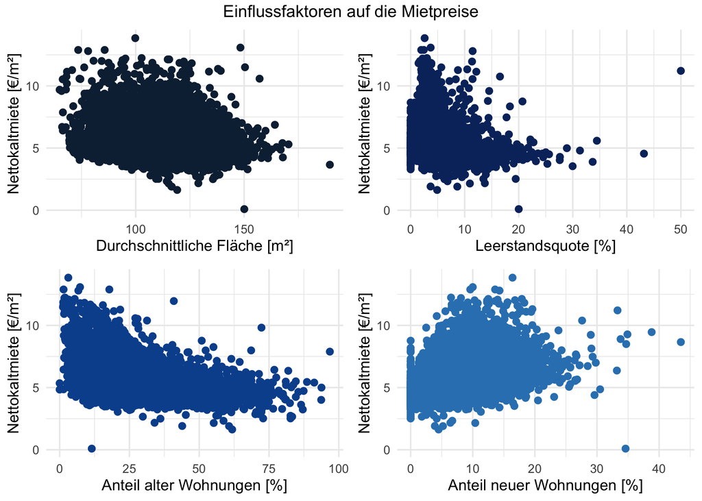

Die vier Punktdiagramme geben einen tiefen Einblick in die Zusammenhänge zwischen den Nettokaltmieten pro Quadratmeter und verschiedenen Einflussfaktoren. Auf der **x-Achse** wird jeweils eine spezifische Variable dargestellt, wie beispielsweise die durchschnittliche Wohnfläche, die Leerstandsquote, der Anteil alter oder neuer Wohnungen in einer Gemeinde. Die **y-Achse** bleibt einheitlich und zeigt die Nettokaltmiete pro Quadratmeter, wodurch die Darstellung der Zusammenhänge klar strukturiert ist.

Das dritte Diagramm beleuchtet den **Anteil alter Wohnungen** und dessen Einfluss auf die Mieten. Gemeinden mit einem hohen Anteil alter Wohnungen (über 50 %) weisen tendenziell niedrigere Quadratmeterpreise auf. Oft liegen diese unter 5 €. Dies ist darauf zurückzuführen, dass ältere Wohnungen häufig nicht den modernen Ansprüchen an Ausstattung, Energieeffizienz oder Komfort entsprechen. Zudem befinden sie sich häufig in wirtschaftlich schwächeren Regionen, was die Nachfrage weiter reduziert und somit die Mietpreise drückt.

Weiterhin wäre es von Interesse in die einzelnen Großstädte Deutschlands genauer hineinzuschauen, um dort auf Besonderheiten im Wohnmarkt einzugehen. Im ersten Schritt sollen Sie Eigenschaften in Bezug auf die Wohnungen genauer untersucht werden, um zu verstehen, welche Faktoren den Mietpreis innerhalb der urbanen Räume beeinflussen könnten. Anschließend wäre es von Interesse, auch die demografischen Merkmale der Mieterinnen und Mieter in den Blick zu nehmen. Dabei stellt sich die Frage, ob und in welchem Maße diese Einfluss auf die Mietpreise und deren Struktur nehmen.

In der vorherigen Aufgabe wurden Zusammenhänge zwischen dem Alter von Wohnungen und dem Mietpreis auf Gemeindeebene untersucht. Nun soll der Fokus darauf liegen, wie sich die Wohnungen in größeren Städten hinsichtlich ihres Alters verteilen.

8. Erstellen Sie ein Balkendiagramm für alle nachfolgenden Städte: `Stuttgart, Landeshauptstadt`, `Ulm, Universitätsstadt`, `Düsseldorf, Stadt`, `Berlin, Stadt`. Betrachten Sie dabei, wie das Alter der Wohnungen zwischen den Städten variiert. Sie sollen analysieren, wie groß der Anteil der Wohnungen abhängig nach den jeweiligen Baujahrsgruppen in den Städten ist. Tragen Sie in ihrem Balkendiagramm den *Anteil der Wohnungen nach den Baujahren* (auf der y-Achse) gegeben der *Baujahre für jede Stadt* (auf der x-Achse) ab.

Beschreiben und interpretieren Sie die Grafik. Haben Sie diese Unterschiede erwartet? Begründen Sie warum oder warum nicht.

*Hinweis:* Denken Sie daran das Faktorvariablen in ggplot hilfreich sein können.

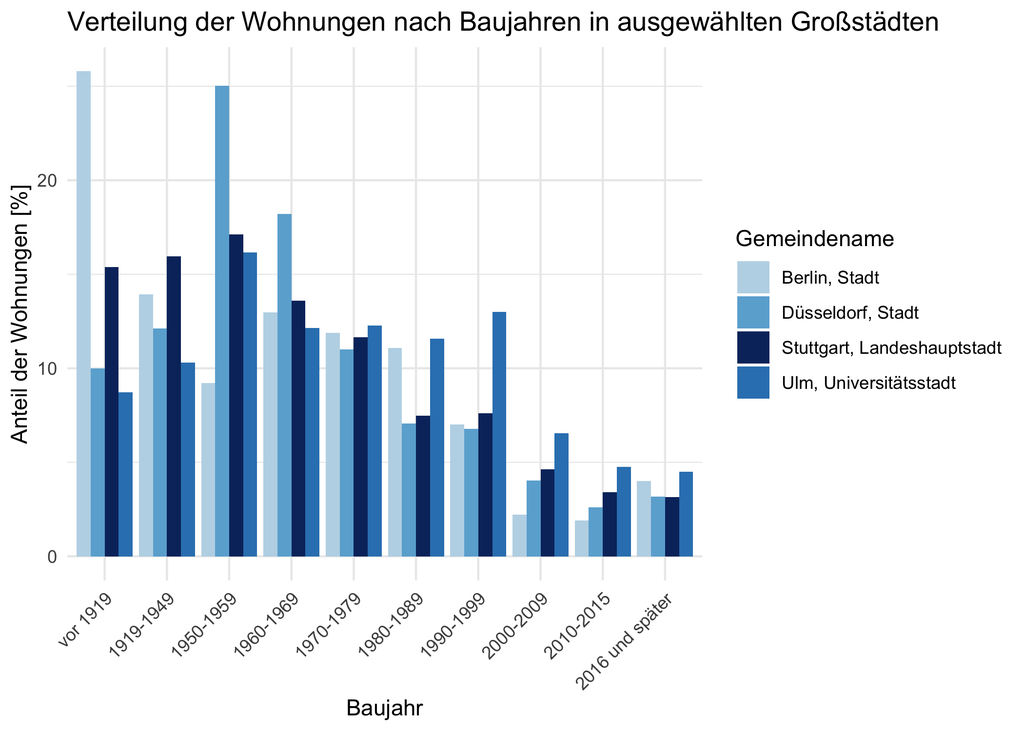

Das Balkendiagramm veranschaulicht die Anteile von Wohnungen, die in verschiedenen Baujahrsgruppen in vier Städten entstanden sind. Dabei zeigt sich eine deutliche Variation, die durch historische, wirtschaftliche und geografische Entwicklungen der Städte geprägt ist.

9. Wie in der vorherigen Aufgabe zu sehen war, unterscheidet sich die Situation in Städten in Bezug auf die jeweiligen Baujahre der Wohnungen deutlich. Es wäre noch spannend zu sehen, ob auch das Alter der Bewohner, die Familienstände, oder die Einwanderungshistorie der Bewohner mit unterschiedlichen Mietpreisen assoziiert sind. Hier sollen Sie in einem ersten generellen Schritt ein paar demografische Faktoren einbeziehen, inwiefern diese eine Auswirkung haben. Betrachten Sie folgende Eigenschaften genauer:
- Familienstand
- Alter der Bewohner
- Einwanderungsgeschichte

Erstellen Sie eine oder mehrere passende Diagramme oder Grafiken für die in Aufgabe 8 aufgeführten Städte.

Beschreiben und interpretieren Sie diese. Haben Sie diese Unterschiede erwartet? Begründen Sie warum oder warum nicht. Wo gibt es Ihrer Ansicht nach besondere Auffälligkeiten? Warum kann es bei der unterschiedlichen Einteilung der Altersgruppen zu Problemen kommen? Was wären Möglichkeiten, um etwaige Probleme zu vermeiden?

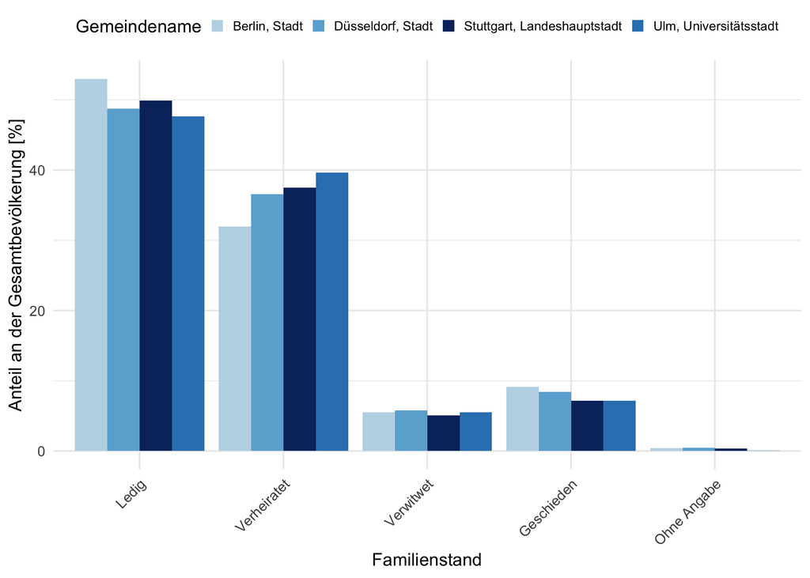

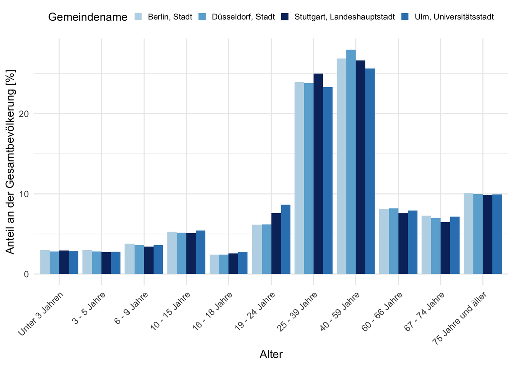

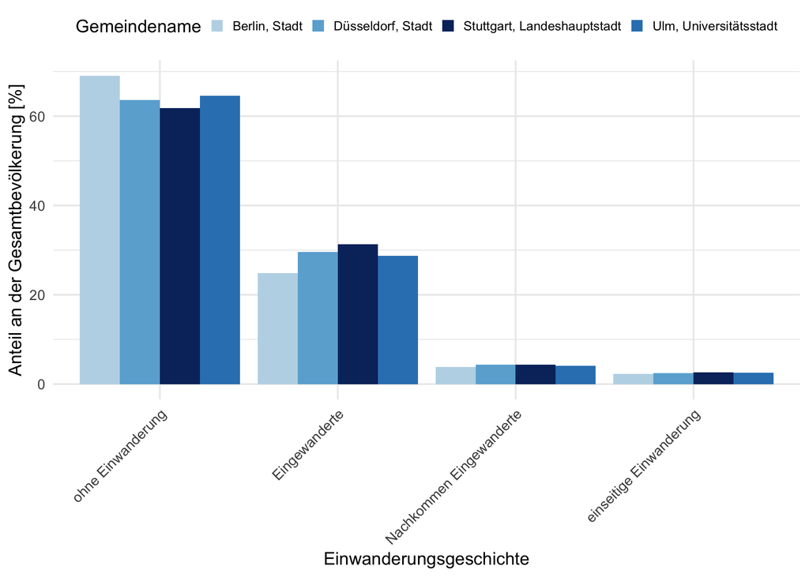

Das erste Balkendiagramm veranschaulicht den prozentualen Anteil an der Gesamtbevölkerung der Stadt bezogen auf den Familienstand. Es ist ganz klar zu erkennen, dass bei allen vier Städten der prozentuale Anteil der Ledigen sehr hoch ist. Dies ist vor allem darauf zurückzuführen, dass Familien mit Kindern eher auf das Land ziehen und nicht in der Stadt bleiben. In der Hauptstadt Berlin dominiert der unverheirateten Status deutlich. Diese Trends sind oft auf die junge und diverse Bevölkerung zurückzuführen.Bei der Stadt Düsseldorf ist im Vergleich zu Berlin eine höhere Anzahl an verheiratetetn Paaren zu beobachten. Düsseldorf hat eine stabilere Familienstruktur, was möglicherweise auf die wirtschaftliche Situation und die hohe Lebensqualität zurückzuführen ist. Ähnlich wie in Düsseldorf gibt es auch in Stuttgart viele verheiratete Paare. In Ulm sind die Unterschiede von verheiratet zu ledig nicht so signifikant wie bei den anderen Städten. Dies lässt sich auf die Große der Stadt zurückführen. Da Ulm im Vergleich zu den anderen Städten eher klein ist, ist die Stadt auch für Familien attraktiv. Dennoch überwiegt der Anteil der Ledigen.

Das zweite Balkendiagramm veranschaulicht den prozentualen Anteil an der Gesamtbevölkerung der Stadt bezogen auf das Alter der Personen. Die Verteilung ist bei allen vier Städten sehr ähnlich. Alle vier Städte haben einen großen Anteil an 25 bis 60 Jährigen. Wie zuvor schon erläutert ziehen Familien eher aufs Land, weswegen in allen vier Städten der Anteil an Personen im Kindesalter sehr gering ist. Erst ab einem Alter von 19 Jahren gibt es einen erheblichen Anstieg im Diagramm. Dies lässt sich durch die Bildungsangebote der Großstädte erklären, denn viele junge Menschen ziehen aufgrund des Studiums oder einer Weiterbildung in die Großstadt.

Das letzte Balkendiagramm veranschaulicht den prozentualen Anteil an der Gesamtbevölkerung der Stadt bezogen auf die Einwanderungsgeschichte. In allen vier Städten ist der Anteil der Personen ohne Einwanderungsgeschichte am höchsten. Auffällig ist jedoch, dass Berlin im Vergleich zu den andern Städten einen geringeren Anteil an Personen mit Einwanderungsgeschichte hat, wo doch Berlin als multikulturelle Stadt bekannt ist. Dies könnte verschiedene Ursachen haben, darunter eine unterschiedliche Integrationspolitik und spezifische wirtschaftliche Rahmenbedingungen. Die geringe Anzahl an Eingewanderten steht damit im Kontrast zu dem Vorurteil, dass Berlin eine der vielfältigsten Städte Deutschlands ist. Im Vergleich ist der Anteil an Personen mit Migrationshintergrund in Stuttgart am höchsten, denn die Stadt profitiert von einer hohen Anzahl an Fachkräften mit Migrationshintergrund, insbesondere in der Automobil- und Technologiebranche. Diese Einwanderer sind oft gut ausgebildet und tragen zur Innovationskraft der Region bei.

Insgesamt lässt sich aus den Diagrammen schließen, dass alle vier Städte eine sehr ähnliche Bevölkerungsstruktur bezüglich des Familienstandes, des Alters und der Einwanderungsgeschichte besitzen. Bei der Betrachtung der Altergruppen kann es jedoch zu Problemen kommen, denn Personen, die sich in der gleichen Altersgruppe befinden, können in unterschiedlichen Lebensphasen sein (z.B. Ausbildung, Berufstätigkeit, Rentenalter). Auch kulturelle Faktoren haben einen Einfluss auf die Lebensphase. Um diese Probleme zu vermeiden können feiner abgestufte Altergruppen oder zusätzliche demografische Merkmale wie Bildungsniveau und Berufstätigkeit herangezogen werden.

In den bisherigen Analysen wurden demografische und wohnungsbezogene Faktoren in verschiedenen Städten Deutschlands untersucht. Dabei lag der Fokus darauf, wie diese Merkmale in unterschiedlichen Regionen das Mietpreisniveau und dessen Struktur beeinflussen. Aufbauend auf diesen Erkenntnissen soll der Blick nun gezielt auf den Vergleich zwischen Ost- und Westdeutschland gelenkt werden. Diese regionale Differenzierung ermöglicht es, potenzielle Unterschiede und Gemeinsamkeiten zwischen den beiden Landesteilen genauer zu analysieren. Insbesondere wird betrachtet, wie sich die Mietpreisstruktur in Ost- und Westdeutschland darstellt und ob sich hierbei spezifische Muster oder Abweichungen erkennen lassen.

10. Betrachten Sie nun die Städte `Dresden, Stadt`, `Chemnitz, Stadt`, `Stuttgart, Landeshauptstadt`, `Ulm, Universitätsstadt`,`Düsseldorf, Stadt`und `Berlin, Stadt`. Vergleichen Sie in einem ersten Schritt die Anzahl an Einwohnern, den Anteil an Menschen, die deutscher Herkunft sind, den Anteil an neuen und alten Wohnungen, sowie die durchschnittlichen Mietpreise. Erweitern Sie ihre Analyse um die durschnittlichen Wohnflächen.

Erstellen Sie für die genannten Städte eine deskriptive Tabelle. Beschreiben und interpretieren Sie diese. Beantworten Sie insbesondere folgende Fragen:

- In wie weit könnte das Alter der Wohnungen eine Rolle für den Mietpreis spielen?
- Gibt es Auffälligkeiten zwischen den einzelnen Städten in Bezug auf Herkunft der Bewohner, Einwohner und Größe der Wohnungen?
- Warum könnte es problematisch sein, wenn Sie die Städte als ein Ganzes betrachten?
- Sind Ihre Ergebnisse auf die ganze Stadt verallgemeinerbar?
- Was sind ihrer Meinung nach Faktoren, die die unterschiedlichen Mietpreise in Ost und West erklären?
- Welche Maßnahmen wären geeignet, um in Düsseldorf, Ulm und Stuttgart die Mietpreisstruktur anzupassen und bezahlbaren Wohnraum zu schaffen?

Statistische Auswertung für ausgewählte Städte

| Stadt | Bevölkerung [Anzahl] | Anteil Deutscher [%] | Neue Wohnungen [%] | Alte Wohnungen [%] | Durchschnittliche Nettokaltmiete [€/m²] | Durchschnittliche Wohnfläche [m²] |
| --- | --- | --- | --- | --- | --- | --- |
| Düsseldorf, Stadt | 611258 | 77.2 | 5.8 | 22.1 | 9.24 | 77.56 |
| Stuttgart, Landeshauptstadt | 610458 | 74.3 | 6.6 | 31.3 | 10.39 | 79.76 |
| Ulm, Universitätsstadt | 127116 | 78.2 | 9.3 | 19.0 | 8.48 | 87.64 |
| Berlin, Stadt | 3596999 | 80.5 | 5.9 | 39.7 | 7.67 | 73.22 |
| Chemnitz, Stadt | 240078 | 90.2 | 3.2 | 41.0 | 5.26 | 71.33 |
| Dresden, Stadt | 557782 | 90.7 | 6.6 | 39.6 | 6.92 | 71.24 |

Das Alter der Wohnungen kann einen erheblichen Einfluss auf die Mietpreise haben. Ältere Wohnungen tendieren dazu, niedrigere Mietpreise aufzuweisen, da sie oftmals mehr Instandhaltung erfordern und weniger moderne Annehmlichkeiten bieten. Da der Anteil älterer Wohnungen in allen untersuchten Städten hoch ist, könnte dies zu durchschnittlich niedrigeren Mietpreisen führen. Im Gegensatz dazu zeichnen sich neue Wohnungen durch moderne Einrichtungen und bessere Energieeffizienz aus, was höhere Mietpreise zur Folge hat.

Eine pauschale Betrachtung der Städte als Ganzes könnte problematisch sein, da jede Stadt unterschiedliche historische, soziale und wirtschaftliche Kontexte aufweist. Diese Vielfalt würde durch eine vereinheitlichende Analyse verwässert, was möglicherweise zu falschen Schlussfolgerungen führen könnte. Jede Stadt verfügt über einzigartige Merkmale und Dynamiken, die berücksichtigt werden müssen.

Die Ergebnisse der Analyse sind zudem nicht ohne Weiteres auf die gesamte Stadt übertragbar. Variablen und Aggregationen sind spezifisch und spiegeln nicht die gesamte städtische Realität wider. Städte bestehen aus diversen Bezirken und Quartieren mit jeweils individuellen Charakteristika, sodass die Ergebnisse lediglich als Indikatoren für bestimmte Bereiche oder Gruppen dienen können.

Die Unterschiede in den Mietpreisen zwischen Ost- und Westdeutschland lassen sich durch verschiedene Faktoren erklären, darunter die historische Entwicklung, der wirtschaftliche Wohlstand, die Demografie und die Investitionen in den Wohnungsbau. Nach der Wiedervereinigung konnten westdeutsche Städte von höheren Investitionen in Neubauten und Renovierungen profitieren, was zu steigenden Mietpreisen führte.

Um in Städten wie Düsseldorf, Ulm und Stuttgart die Mietpreisstruktur anzupassen und bezahlbaren Wohnraum zu schaffen, wären verschiedene Maßnahmen geeignet. Der Bau von mehr Sozialwohnungen könnte eine unmittelbare Entlastung schaffen. Darüber hinaus könnten Anreize für private Investoren zur Schaffung von günstigem Wohnraum gesetzt werden. Mietpreisregulierungen könnten dabei helfen, einen Anstieg der Preise einzudämmen. Zudem könnten Renovierungsprogramme ältere Wohnbestände aufwerten und gleichzeitig die Erschwinglichkeit erhalten.

11. Lesen Sie den [folgenden Artikel](https://www.tagesschau.de/wirtschaft/sozialwohnungen-bau-mangel-101.html). Dort werden Sozialwohnungen thematisiert, warum so viele fehlen und wer davon vor allem betroffen ist. Beantworten Sie anschließend folgende Fragen:
- Welche Bevölkerungsgruppen sind am stärksten von der Sozialwohnungsnot betroffen und inwiefern?
- Was sind Gründe, warum es zu wenige Sozialwohnungen gibt?
- Wie sieht die historische Entwicklung des Sozialwohnungsbaus aus, im Hinblick auf Vorhandensein von Wohnungen und Investitionen in den Bau von neuen Wohnungen?
- Welche Anreize könnten Investoren motivieren, mehr Sozialwohnungen zu bauen?
- Welche innovativen Ansätze können Bauherren verfolgen, um die Kosten für den Wohnungsbau zu senken?

Die Sozialwohnungsnot betrifft vor allem einkommensschwache Haushalte, darunter Alleinerziehende, Geringverdiener und Familien, die trotz Wohnberechtigungsschein häufig keine Wohnung finden können, da das Angebot stark begrenzt ist.

Der Mangel an Sozialwohnungen wird durch hohe Baukosten, steigende Zinsen, den Mangel an Fachkräften im Bauwesen und bürokratische Hürden verstärkt. Zudem fallen jährlich viele Sozialwohnungen aus der Mietpreisbindung.

Historisch gesehen ist die Zahl der Sozialwohnungen seit den 1990er Jahren von drei Millionen auf rund 1,1 Millionen gesunken, da Investitionen in den Wohnungsbau nachgelassen haben.

Um Investoren zu motivieren, mehr Sozialwohnungen zu bauen, könnten höhere Förderungen, steuerliche Erleichterungen und vereinfachte Genehmigungsprozesse angeboten werden.

Innovative Bauansätze wie der Einsatz von Holzbauweisen, modularem Bauen oder einfacheren Bauvorgaben könnten dazu beitragen, die Baukosten zu senken und den Wohnungsbau effizienter zu gestalten.

12. Gerade die Politik ist gefordert, bezahlbaren Wohnraum zu realisieren. Dabei gibt es eine Viezahl an politischen Maßnahmen, die aufgestellt wurden und umfangreich diskutiert werden. Betrachten Sie die folgenden Maßnahmen, welche helfen sollen, die angespannte Lage auf dem Mietmarkt zu entlasten. Argumentieren Sie, warum diese Maßnahmen sinnvoll/nicht sinnvoll sind und in welcher Art und Weise diese umgesetzt werden können.
1. “Fachleute fordern, die Regulierung von Bestandsmieten zu lockern, damit sich ihr Niveau den Neuvertragsmieten annähert, mehr Menschen umziehen und sich Wohnraum besser verteilt.”
2. “Eine weitere Möglichkeit wäre, Mieterhöhungen bei Neuvertragsmieten zu begrenzen.”
3. “Am einfachsten ist es, wenn vor allem in Großstädten, wo bezahlbarer Wohnraum fehlt, mehr gebaut wird.”
4. “Am besten wäre es, wenn zukünftig mehr Vermieter in regelmäßigen Abständen die Miete anpassen.”

Die politische Diskussion über Maßnahmen zur Entlastung des Mietmarkts umfasst verschiedene Ansätze, die jeweils Vor- und Nachteile mit sich bringen.

Eine Lockerung der Regulierung von Bestandsmieten könnte die Flexibilität erhöhen und Umzüge fördern, was die Wohnraumverteilung verbessern würde. Allerdings könnte diese Maßnahme sozial schwächere Mieter stark belasten, wenn Mieten drastisch steigen.

Eine Begrenzung von Mieterhöhungen bei Neuvertragsmieten ist sinnvoll, um das Preisniveau stabil zu halten und Verdrängung zu verhindern. Dies könnte aber das Neubauangebot beeinträchtigen, wenn Investoren zu wenig Anreize sehen.

Der Neubau von Wohnungen in Großstädten ist die offensichtliche Lösung zur Bekämpfung der Wohnungsknappheit, allerdings ist die Schaffung von bezahlbarem Wohnraum aufgrund hoher Baukosten und bürokratischer Hürden oft schwierig.

Regelmäßige Mietanpassungen durch Vermieter könnten den Markt stabilisieren und verhindern, dass Vermieter durch unregelmäßige, hohe Erhöhungen überfordert werden. Allerdings könnte diese Maßnahme in begehrten Regionen zu einer weiteren Mietbelastung führen, weshalb die Umsetzung unter Berücksichtigung der Marktbedingungen und der Mieterrechte erfolgen sollte.

Alle diese Maßnahmen benötigen eine sorgfältige und ausgewogene Umsetzung, um sowohl den Bedürfnissen der Mieter als auch den Anforderungen des Marktes gerecht zu werden.

# Einzelne Stadtteile in Deutschland

In allen vorherigen Aufgaben haben Sie die Städte, Gemeinden oder auch Landkreise immer als ein Ganzes betrachtet. Jedoch ist es schwierig gerade in Großstädten wie Berlin, Düsseldorf oder auch Stuttgart allgemeine Aussagen über die Mietsituation auf Stadtebene zu treffen. Dies liegt unter anderem daran, dass unterschiedliche Stadtviertel unterschiedliche demografische Eigenschaften, sowie eine unterschiedliche Mietstruktur aufweisen können. Hier wäre es sinnvoll sich mit dem Stadtbild und der Verteilung der Mieten genauer auseinanderzusetzen, um zu sehen, wie sich Mieten innerhalb der Stadt verteilen. Wie in Aufgabe 10 zu sehen war, weisen die Städte im Westen Deutschlands untereinander, sowie die Städte im Osten ähnliche Merkmale auf, weshalb Sie sich in den folgenden Aufgaben auf je eine große und eine kleinere Stadt aus beiden Regionen konzentrieren.

13. In dieser Aufgabe sollen Sie ihren Datensatz aus Aufgabe 4, bei dem Sie Kartendaten und Informationen zu Mieten und LEQ auf 1km-Gitterebene heruntergeladen und zusammengefügt haben, verwenden und vier Karten zeichnen, welche die Verteilung der Nettokaltmieten in den Stadtteilen der Städte “Stuttgart, Landeshauptstadt”, “Ulm, Universitätsstadt”, “Chemnitz, Stadt” und “Dresden, Stadt” anschaulich visualisieren.

Erstellen Sie vier Grafiken, beschreiben und interpretieren diese. Gehen Sie insbesondere auf folgende Fragen ein:

- Welche Besonderheiten fallen Ihnen bei diesen Städten auf?
- Gibt es eine Segregation in Bezug auf die Mieten in einzelnen Stadtteilen?
- Falls es eine Segregation gibt, welche Konsequenzen könnte dies haben?
- Welche Rolle spielen geografische oder infrastrukturelle Faktoren bei den Mietpreisen?
- Gibt es Unterschiede zwischen Städten im Osten und Westen Deutschlands, falls ja, welche Einflüsse in Bezug auf Wirtschaft und Arbeitsmarkt könnte dies in den jeweiligen Städten haben?

*Hinweis:* Wenn Sie einheitliche Legenden für die Karten haben möchten und die vier Städte nebeneinander oder untereinander darstellen wollen, so empfiehlt sich das Paket `ggpubr` und dort der Befehl `ggarrange`.

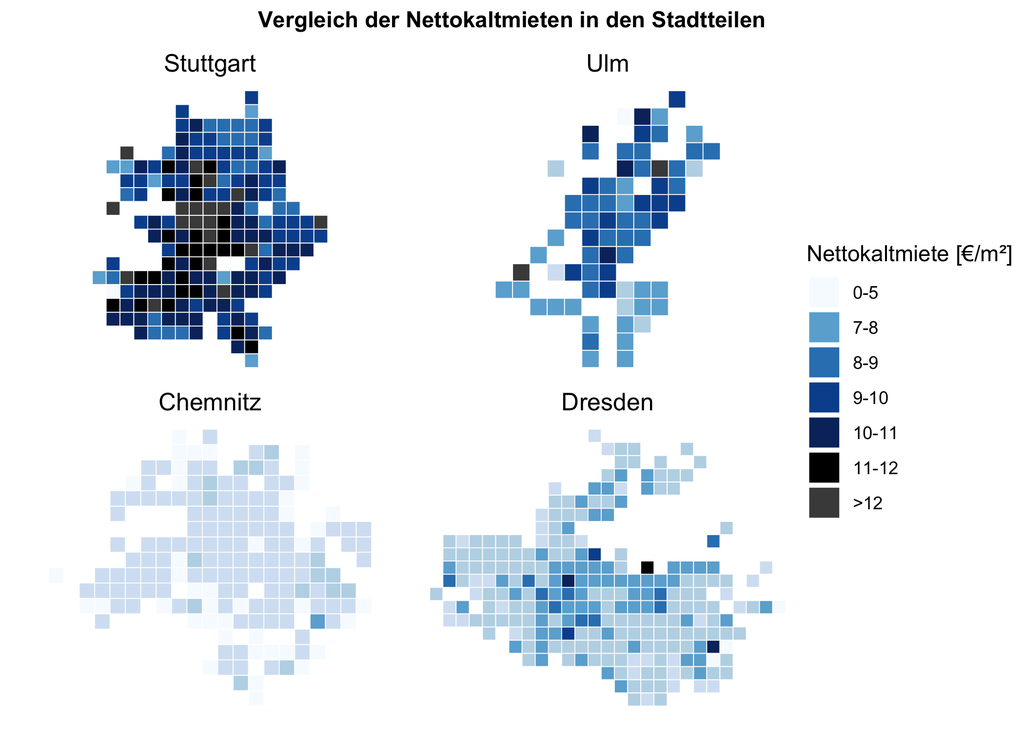

Die Karten zu den Nettokaltmieten in Stuttgart, Ulm, Chemnitz und Dresden veranschaulichen die räumlichen Unterschiede der Mietpreise innerhalb der Städte. Dabei lassen sich spezifische Muster und Dynamiken in Bezug auf städtische Segregation, geografische und infrastrukturelle Faktoren sowie regionale Unterschiede zwischen Ost- und Westdeutschland erkennen.

In Stuttgart zeigt sich eine hohe räumliche Differenzierung der Mietpreise. Besonders die zentralen und südlichen Lagen weisen sehr hohe Mietpreise auf, während in Randgebieten geringere Preise dominieren. Diese Muster deuten auf eine starke wirtschaftliche Dynamik und Nachfrage in den innerstädtischen Bereichen hin. Ulm hingegen zeigt ein homogeneres Bild, wobei die höchsten Mieten ebenfalls in zentralen Bereichen zu finden sind, jedoch weniger stark ausgeprägt als in Stuttgart. Chemnitz präsentiert sich mit deutlich niedrigeren Mietniveaus und einer weitgehend homogenen Verteilung, während Dresden im Vergleich zu Chemnitz stärkere Mietsegregation zeigt. Hier konzentrieren sich die hohen Mieten in zentralen Lagen und entlang von Achsen mit guter infrastruktureller Anbindung.

In Bezug auf Segregation ist diese in Stuttgart und Dresden besonders ausgeprägt. In Stuttgart konzentrieren sich hohe Mietpreise auf privilegierte Gebiete, was zu einer Verdrängung einkommensschwächerer Haushalte in weniger attraktive Stadtteile führen kann. Auch in Dresden zeigt sich eine zunehmende räumliche Trennung, während Chemnitz durch seine Homogenität ein geringeres Segregationsrisiko aufweist. In Ulm gibt es leichte Differenzen, die jedoch nicht so stark ins Gewicht fallen wie in Stuttgart oder Dresden. Die Konsequenzen der Segregation könnten längere Pendelwege für einkommensschwächere Gruppen und eine geringere soziale Durchmischung sein, was wiederum die soziale Ungleichheit verstärken könnte.

Geografische und infrastrukturelle Faktoren spielen eine entscheidende Rolle bei den Mietpreisen. In Stuttgart beeinflusst die Topografie, insbesondere Hanglagen und Aussichtspunkte, die Attraktivität bestimmter Stadtteile. Dresden profitiert von der Nähe zur Elbe sowie kulturellen und wirtschaftlichen Zentren, die hohe Mietpreise anziehen. Chemnitz und Ulm zeigen weniger Einfluss geografischer Besonderheiten, wobei in Ulm die Nähe zur Universität einen leichten Einfluss hat.

Die Unterschiede zwischen Ost- und Westdeutschland sind signifikant. Die Mietpreise in Chemnitz und Dresden sind im Vergleich zu Stuttgart und Ulm deutlich niedriger. Dies spiegelt die wirtschaftliche Stärke und den Arbeitsmarkt wider: Während Stuttgart und Ulm von einer starken Wirtschaft und hohen Einkommen profitieren, sind Chemnitz und Dresden von niedrigeren Löhnen und einer langsameren wirtschaftlichen Entwicklung geprägt. Besonders in Chemnitz scheint der Wohnungsmarkt weniger unter Druck zu stehen, was sich in einer stabilen, niedrigen Mietstruktur äußert.

Zusammenfassend lässt sich sagen, dass die Karten einen klaren Einblick in die Mietdynamik der vier Städte geben. Westdeutsche Städte zeigen eine stärkere wirtschaftliche Dynamik und räumliche Differenzierung, während ostdeutsche Städte durch Homogenität und geringeren Mietdruck gekennzeichnet sind. Diese Unterschiede machen deutlich, wie stark wirtschaftliche und infrastrukturelle Faktoren die Lebensqualität und die soziale Struktur in Städten beeinflussen können.

14. Nachdem Sie in Aufgabe 13 die Verteilung der Mieten der einzelnen Stadtteile visualisiert haben, sollten Sie in dieser Aufgabe den Anteil der Leerstandsquoten in den Stadtteilen der Städte “Stuttgart, Landeshauptstadt”, “Ulm, Universitätsstadt”, “Chemnitz, Stadt” und “Dresden, Stadt” veranschaulichen.

Erstellen Sie vier Grafiken, beschreiben und interpretieren diese. Gehen Sie insbesondere auf folgende Fragen ein:

- Was könnten Gründe sein, dass die Leerstandsquote in bestimmten Stadtteilen höher ist, als in anderen?
- Welche Besonderheiten fallen Ihnen bei diesen Städten auf? Auch im Hinblick auf ihre Erkenntnisse aus Aufgabe 13.
- Vergleichen Sie die Grafiken aus Aufgabe 13 und Aufgabe 14. Was könnte der Grund für die unterschiedlichen Muster sein?
- Welche Maßnahmen ergreifen Städte mit hohen Leerstandsquoten, um diese zu reduzieren?

*Hinweis:* Wenn Sie einheitliche Legenden für die Karten haben möchten und die vier Städte nebeneinander oder untereinander darstellen möchten, so empfiehlt sich das Paket `ggpubr` und dort der Befehl `ggarrange`.

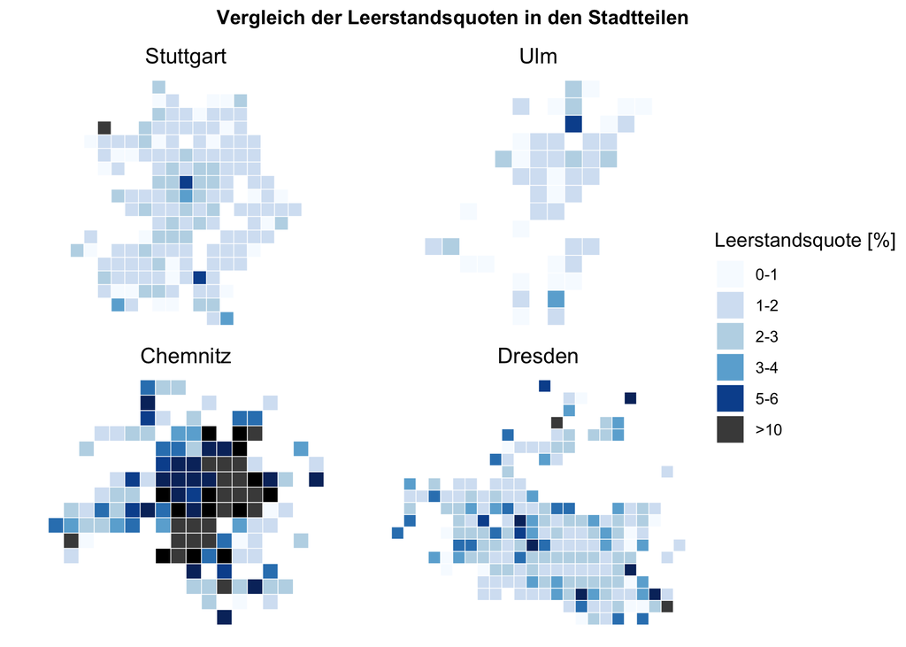

Die vier Karten zur Leerstandsquote in Stuttgart, Ulm, Chemnitz und Dresden zeigen deutliche Unterschiede zwischen den Städten. Diese Unterschiede können auf verschiedene Gründe zurückgeführt werden. In bestimmten Stadtteilen kann die Leerstandsquote höher sein, weil diese Gebiete wirtschaftlich schwächer sind oder schlechter erreichbar. Auch unrenovierte und alte Gebäude führen oft zu höheren Leerständen, weil sie für viele potenzielle Mieter unattraktiv sind. In Städten wie Chemnitz, in denen viele Menschen wegziehen, ist die Leerstandsquote besonders hoch. Auch die allgemeine wirtschaftliche Lage einer Stadt spielt eine Rolle: Städte mit einer schwächeren Wirtschaft, wie Chemnitz, haben eher mit leerstehenden Wohnungen zu kämpfen, während wirtschaftlich starke Städte wie Stuttgart weniger Probleme mit Leerstand haben.

Die Besonderheiten der vier Städte zeigen ebenfalls Unterschiede. Stuttgart ist eine wirtschaftlich sehr starke Stadt, mit vielen Arbeitsplätzen und einer hohen Nachfrage nach Wohnraum, was zu einer sehr niedrigen Leerstandsquote führt. In den zentralen Gebieten sind die Mieten zwar hoch, aber auch die Nachfrage ist entsprechend groß. Ulm zeigt ein ähnliches Bild, jedoch weniger extrem als Stuttgart. Auch hier sind die Mieten in den zentralen Bereichen höher, aber insgesamt ist der Unterschied zwischen den Stadtteilen weniger ausgeprägt. Chemnitz und Dresden haben dagegen eine deutlich höhere Leerstandsquote, was vor allem auf die wirtschaftliche Schwäche dieser Städte und den damit verbundenen Bevölkerungsrückgang zurückzuführen ist. In Chemnitz gibt es viele leerstehende Wohnungen, während Dresden, obwohl es ebenfalls höhere Leerstände als Stuttgart und Ulm aufweist, dennoch nicht so extrem betroffen ist.

Wenn man die Karten zur Mietpreisentwicklung aus Aufgabe 13 mit den Karten zur Leerstandsquote vergleicht, wird ein klarer Zusammenhang sichtbar. In den Städten Stuttgart und Ulm, wo die Mieten relativ hoch sind, gibt es auch eine niedrige Leerstandsquote. Dies zeigt, dass in diesen Städten die Nachfrage nach Wohnraum hoch ist und es weniger leerstehende Wohnungen gibt. In Chemnitz und Dresden, wo die Mieten niedriger sind, gibt es deutlich mehr Leerstände. Das deutet darauf hin, dass diese Städte trotz günstigerer Mietpreise nicht so viele Menschen anziehen können, was zu einem höheren Leerstand führt. Die Unterschiede zwischen Ost- und Westdeutschland sind hier ebenfalls erkennbar: In den westdeutschen Städten Stuttgart und Ulm gibt es eine starke wirtschaftliche Dynamik, während in den ostdeutschen Städten Chemnitz und Dresden der wirtschaftliche Druck deutlich höher ist, was zu einer höheren Leerstandsquote führt.

Städte mit hohen Leerstandsquoten, wie zum Beispiel Chemnitz und Dresden, ergreifen verschiedene Maßnahmen, um den Leerstand zu reduzieren. Dazu gehören die Sanierung und Renovierung leerstehender Gebäude, die Umnutzung von Gebäuden für andere Zwecke, wie Büros oder Wohnräume für bestimmte Zielgruppen, sowie Förderprogramme, die darauf abzielen, mehr Menschen und Unternehmen in diese Gebiete zu locken. Auch die Verbesserung der Infrastruktur, etwa durch den Ausbau des öffentlichen Verkehrs, spielt eine Rolle, um diese Stadtteile für die Bewohner attraktiver zu machen. In Städten wie Stuttgart und Ulm, wo es bereits weniger Leerstand gibt, konzentrieren sich die Maßnahmen eher darauf, noch mehr Wohnraum zu schaffen und die Lebensqualität weiter zu erhöhen, um der hohen Nachfrage gerecht zu werden.

Zusammenfassend lässt sich sagen, dass die Leerstandsquote in den vier Städten von einer Vielzahl von Faktoren beeinflusst wird. In wirtschaftlich starken Städten wie Stuttgart und Ulm ist der Leerstand gering, während in Städten mit schwächerer Wirtschaft wie Chemnitz und Dresden deutlich mehr Wohnungen leer stehen. Auch die Mietpreise und die Nachfrage nach Wohnraum spielen eine zentrale Rolle. Die Maßnahmen, die von den Städten ergriffen werden, zielen darauf ab, den Leerstand zu reduzieren und die Städte lebendig zu halten, wobei jede Stadt unterschiedliche Ansätze verfolgt, je nach den eigenen Herausforderungen.

15. Die aktuellen Mietpreise und deren Entwicklungen hindern in Deutschland immer mehr Menschen daran, dass sie sich eine neue geeignete Wohnung suchen. Personen, die aufgrund ihrer aktuellen Lebenssituation sich nach einer neuen Wohnung umsehen, finden oft keine oder können sich diese nicht leisten. Doch worin liegen die Ursachen und Probleme?

Beantworten Sie hierzu folgende Fragen:

- Was versteht man unter dem Lock-in-Effekt, speziell in Bezug auf den Mietmarkt? Wer ist davon vor allem betroffen und warum?
- Gibt es aktuell Möglichkeiten, die vor allem diese “betroffenen” Personen haben, um an bezahlbaren Wohnraum zu gelangen?
- Worin liegen die Ursachen, dass Bestandsmieten (Mieten aus bestehenden Verträgen) und Angebotsmieten (Mieten aus Neuverträgen) so stark voneinander abweichen?

Gehen Sie in ihrer Argumentation auch auf die Grafiken und Ergebnisse der Aufgaben 11, 13 und 14 ein.

Der Lock-in-Effekt auf dem Mietmarkt beschreibt die Situation, in der Mieter in ihrer aktuellen Wohnung bleiben, obwohl sie möglicherweise eine günstigere oder besser geeignete Wohnung finden könnten. Dies geschieht oft aufgrund der hohen Kosten und der Komplexität eines Umzugs, der mit Umzugsgebühren, der Suche nach einer passenden Wohnung und der Anpassung an eine neue Umgebung verbunden ist. Besonders betroffen sind Mieter, die in langjährigen Mietverhältnissen leben und von den niedrigeren Bestandsmieten profitieren. Da diese oft deutlich unter den aktuellen Marktpreisen liegen, zögern viele, ihre Wohnung aufzugeben, selbst wenn sie eine Veränderung ihrer Lebenssituation benötigen. Besonders einkommensschwache Haushalte, Alleinerziehende und Geringverdiener sind betroffen, da sie sich oft keine neuen, teureren Wohnungen leisten können und in ihrer bisherigen Wohnung bleiben müssen, um nicht zusätzlich mit hohen Mietpreiserhöhungen konfrontiert zu werden.

Aktuell haben diese betroffenen Personen begrenzte Möglichkeiten, an bezahlbaren Wohnraum zu gelangen. Eine Option sind Sozialwohnungen, die allerdings stark limitiert sind und lange Wartezeiten mit sich bringen. Auch die Wohnberechtigungsscheine sind nur für bestimmte Personengruppen zugänglich, was die Möglichkeiten für viele einkommensschwächere Mieter einschränkt. Alternativ könnten private Mietwohnungen in weniger nachgefragten Stadtteilen oder die Teilnahme an Genossenschaften in Betracht gezogen werden. Diese Optionen bieten jedoch auch nicht immer eine langfristige Lösung, da der Markt stark umkämpft ist.

Die Ursachen für die starke Abweichung zwischen Bestandsmieten und Angebotsmieten sind vielfältig. Ein wesentlicher Grund liegt in den deutlich höheren Neubaukosten und der allgemeinen Entwicklung des Wohnungsmarktes. Neubauten, die oft auf die Nachfrage in gut angebundenen städtischen Lagen reagieren, sind teuer in der Errichtung, was zu höheren Angebotsmieten führt. In Bestandswohnungen, die bereits zu günstigeren Preisen vermietet wurden, bleiben die Mieten aufgrund der vertraglichen Vereinbarungen und der geringeren Inflation in den letzten Jahren meist niedriger. Zudem haben Investoren und Vermieter in den letzten Jahren zunehmend auf höherpreisige Neubauten gesetzt, wodurch das Angebot an günstigen Wohnungen immer weiter schrumpft. Besonders in Städten wie Stuttgart oder München, die eine hohe Nachfrage nach Wohnraum haben, können die Differenzen zwischen Bestandsmieten und Neubau-Mietpreisen sehr groß ausfallen.

Die Grafiken und Ergebnisse aus den Aufgaben 11, 13 und 14 belegen diese Unterschiede weiter. In den untersuchten Städten zeigt sich, dass vor allem wirtschaftlich starke Städte wie Stuttgart und Ulm von hohen Mietpreisdifferenzen betroffen sind, da der Wohnraum dort stark nachgefragt wird. In diesen Städten führen der Lock-in-Effekt und die hohe Nachfrage dazu, dass einkommensschwächere Gruppen immer weniger Zugang zu bezahlbarem Wohnraum haben. Im Vergleich dazu zeigen Städte wie Chemnitz und Dresden eine größere Homogenität der Mietpreise und auch eine höhere Leerstandsquote, was auf eine insgesamt schwächere wirtschaftliche Situation und geringere Mietsteigerungen hinweist. Diese regionalen Unterschiede spiegeln sich auch in den Differenzen zwischen Bestandsmieten und Angebotsmieten wider. Während in den westdeutschen Städten die Abweichung deutlich größer ist, sind die Mieten in vielen ostdeutschen Städten weniger stark gestiegen, was teilweise auch zu höheren Leerständen führt.

Zusammenfassend lässt sich sagen, dass der Lock-in-Effekt und die Ursachen für die Diskrepanz zwischen Bestandsmieten und Angebotsmieten stark mit der wirtschaftlichen Situation, den hohen Neubaukosten und der zunehmenden Segregation des Wohnungsmarktes zusammenhängen. Besonders betroffen sind einkommensschwächere Haushalte, die durch diese Entwicklung zunehmend von bezahlbarem Wohnraum ausgeschlossen werden.

# Stadt vs. Land

Bisher haben Sie sich intensiv mit der Wohnsituation in Deutschland auseinandergesetzt und dabei insbesondere die Unterschiede zwischen Ost- und Westdeutschland betrachtet. Im Fokus standen dabei die Mietpreisentwicklung und die Rolle verschiedener Faktoren wie demografische Merkmale, Leerstandsquote, Eigentümerquote, sowie die Wohnfläche. Diese Analysen haben wertvolle Erkenntnisse über die regionale Dynamik des Mietmarkts geliefert.

Nun sollen Sie ihren Blickwinkel erweitern und den Fokus auf eine weitere Ebene der Analyse richten. Im Kern sollen Sie den Unterschied zwischen städtischen Regionen, insbesondere Großstädten, und ländlichen Gebieten untersuchen. Hierbei soll die Mietstruktur in diesen beiden Raumtypen analysiert werden, ob sich die Strukturen von Stadt und Land voneinander unterscheiden.

16. Betrachten Sie in einem ersten Schritt die Wohnungen abhängig ihres Alters. Erstellen Sie dazu eine passende Grafik, die die Verteilung der Wohnungen nach Altersgruppen für die Stadt `Stuttgart, Landeshauptstadt` (Landkreis: Stuttgart, Stadtkreis) im Vergleich zum `Alb-Donau-Kreis` und `Ostalbkreis` darlegt.

Beschreiben und interpretieren Sie ihre Grafik. Woran könnte es liegen, dass es in Stuttgart (in der Stadt) deutlich mehr Altbauwohnungen als auf dem Land gibt? Könnten politische Maßnahmen ihrer Ansicht nach helfen, dass auch in Großstädten mehr neue Wohnungen erbaut und zur Vermietung zur Verfügung gestellt werden?

*Hinweis 1:* Nutzen Sie für die Visualisierung einen Mosaik- oder ein “stacked” Balkendiagramm. Eine Idee, wie Sie das Ganze darstellen können, finden Sie [hier](https://r-graph-gallery.com/).

*Hinweis 2:* Für Stuttgart soll der komplette Landkreis (“Stadtkreis”) untersucht werden.

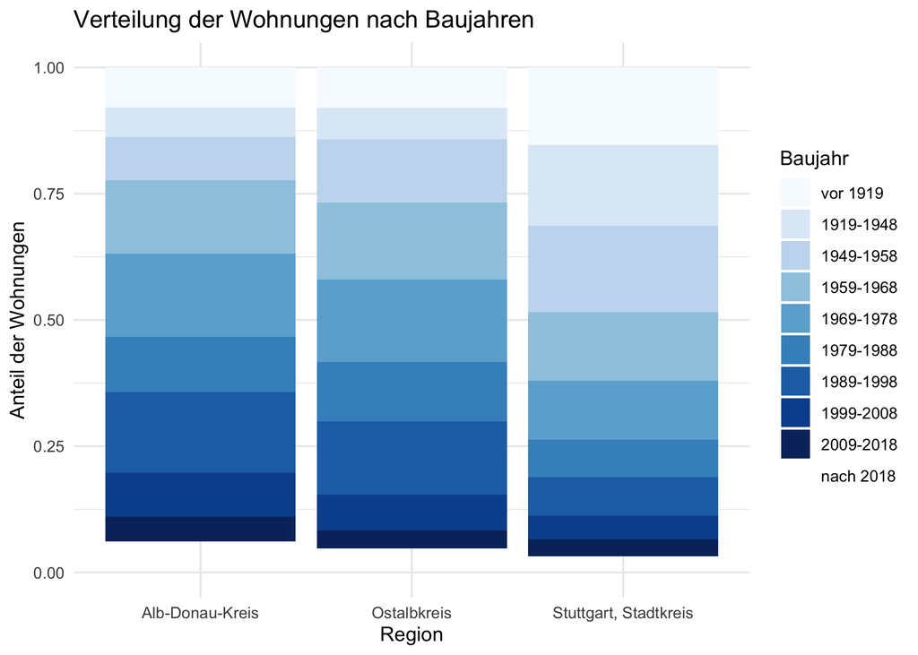

Die Analyse der Altersstruktur von Wohnungen zeigt deutliche Unterschiede zwischen der Stadt Stuttgart und den ländlichen Regionen Alb-Donau-Kreis und Ostalbkreis. In Stuttgart gibt es einen hohen Anteil an Altbauwohnungen, insbesondere solche, die vor 1948 erbaut wurden. Dies ist typisch für Großstädte mit einer langen Geschichte und begrenztem Platz für Neubauten. In den ländlichen Regionen hingegen dominieren jüngere Wohnungen, die überwiegend nach den 1950er Jahren entstanden sind, da hier mehr Bauflächen verfügbar sind.

Die hohe Anzahl an Altbauten in Stuttgart lässt sich auf den historischen Stadtcharakter und den Schutz historischer Bausubstanz zurückführen. Auf dem Land hingegen begünstigen Platzverfügbarkeit und geringere Bebauungsdichte den Bau neuerer Wohngebäude. Politische Maßnahmen könnten dazu beitragen, auch in Städten mehr Neubauwohnungen zu schaffen. Dazu gehören beispielsweise steuerliche Anreize für Bauunternehmen, die Lockerung von Bauvorschriften zur Schaffung höherer Gebäude und die gezielte Förderung von Renovierungsprojekten, um bestehenden Wohnraum effizienter zu nutzen und die Wohnsituation insgesamt zu verbessern.

In einem weiteren Schritt sollen Sie nun die Mietpreise und deren Verteilung analysieren. Hierbei sollen Sie neben der Leerstands- und Eigentümerquote auch auf die Verteilung der Wohnungen nach deren Wohnfläche achten und diese untersuchen.

17 (a). Erstellen Sie zuerst eine Tabelle, die die durchschnittlichen Mietpreise mit der Leerstands- und Eigentümerquote darstellt. Was fällt ihnen dabei besonders auf? Beschreiben und interpretieren Sie ihre Tabelle.

17 (b). Erstellen Sie eine weitere Grafik, die die Verteilung der Wohnungen nach den einzelnen Wohnungsgrößen(<40m² bis >=200m²) abbildet. Stellen Sie darüber hinaus den durchschnittlichen Mietpreis je Landkreis in einer weiteren Grafik dar. Beschreiben und interpretieren Sie ihre Grafiken. Gehen Sie insbesondere auf die Frage ein, ob es Sinn macht sich vor allem den Ostalbkreis oder Alb-Donau-Kreis als ein Ganzes anzusehen und inwieweit überhaupt ein Vergleich zwischen Stadt und ländlicher Region möglich ist.

*Hinweis:* Hier sollen Sie erneut auf dieselben Städte und Landkreise aus Aufgabe 16 eingehen!

Durchschnittliche Mietpreise, Leerstands- und Eigentümerquote

| Region | Nettokaltmiete [€/m²] | Leerstandsquote [%] | Eigentümerquote [%] |
| --- | --- | --- | --- |
| Alb-Donau-Kreis | 6.37 | 5.34 | 71.44 |
| Ostalbkreis | 6.27 | 5.09 | 70.59 |
| Stuttgart, Stadtkreis | 10.39 | 3.46 | 31.15 |

Die Analyse der Mietpreise, Leerstandsquote und Eigentümerquote zeigt deutliche Unterschiede zwischen dem Alb-Donau-Kreis, dem Ostalbkreis und Stuttgart, Stadtkreis. Während die Werte für den Alb-Donau-Kreis und den Ostalbkreis nahezu identisch sind, hebt sich Stuttgart durch deutlich höhere Mietpreise sowie niedrigere Leerstands- und Eigentümerquoten ab. Diese Unterschiede lassen sich durch die hohe Nachfrage nach Mietwohnungen in der Stadt erklären. Da der Wohnungsmarkt von Angebot und Nachfrage geprägt ist, sind die Menschen bereit, höhere Mieten zu zahlen, um eine Wohnung zu finden. Gleichzeitig besteht eine enge Verbindung zwischen Miet- und Verkaufspreisen: Die Kaufpreise für Wohnungen in der Stadt liegen erheblich über denen auf dem Land. Dies erschwert den Wohnungskauf in der Stadt, was wiederum die deutlich niedrigere Eigentümerquote in urbanen Gebieten im Vergleich zum ländlichen Raum erklärt.

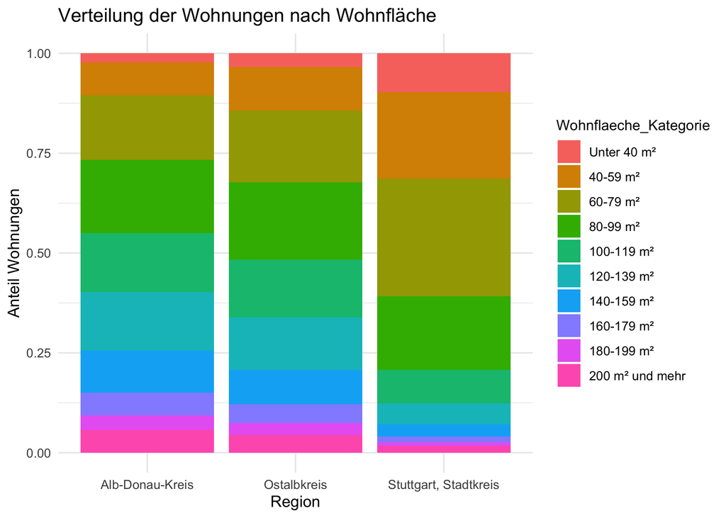

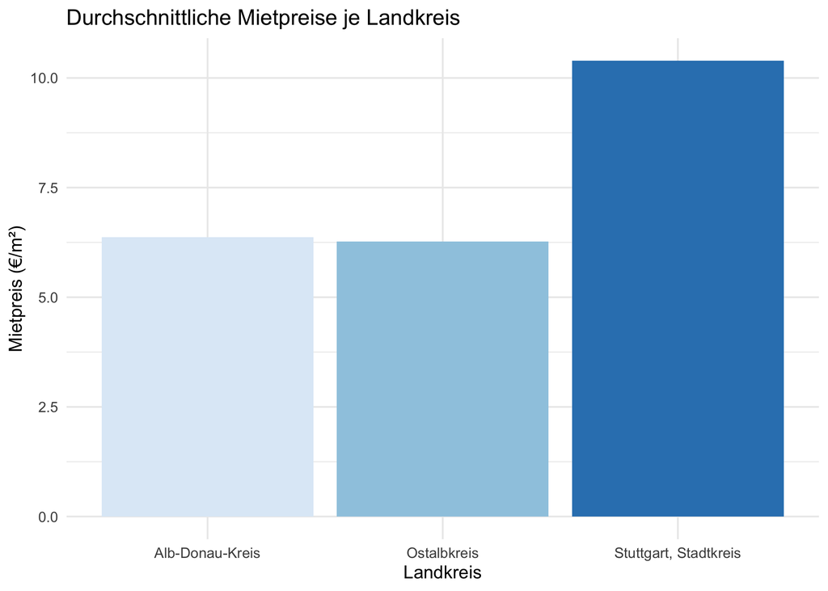

Die Verteilung der Wohnungen zeigt, dass die meisten Wohnungen eine Wohnfläche zwischen 40 und 120 Quadratmetern haben. Diese Größenordnung ist für Single-Haushalte bis hin zu fünfköpfigen Familien ausreichend und deckt somit die Bedürfnisse des Großteils der Bevölkerung ab.

Die durchschnittlichen Mietpreise unterscheiden sich je nach Landkreis deutlich. Auf dem Land, insbesondere in Regionen wie dem Alb-Donau-Kreis und dem Ostalbkreis, sind die Mieten erheblich niedriger als in der Stadt. Ein Vergleich dieser beiden ländlichen Kreise zeigt, dass ihre Werte für Mietpreis, Leerstandsquote und Eigentümerquote nahezu identisch sind. Dies deutet auf eine ähnliche Struktur und Wohnsituation in diesen Regionen hin. Es könnte daher sinnvoll sein, den Alb-Donau-Kreis und den Ostalbkreis bei bestimmten Analysen und Planungen als eine Einheit zu betrachten, um allgemeine Trends und Muster in ländlichen Gebieten zu erkennen.

Im Gegensatz dazu weist Stuttgart als städtische Region deutliche Unterschiede im Vergleich zu den ländlichen Kreisen auf. Die Mietpreise in Stuttgart sind deutlich höher, was auf die hohe Nachfrage nach Wohnraum in der Stadt zurückzuführen ist. Hier sind Arbeitsplätze, Bildungseinrichtungen und Freizeitanlagen konzentriert, was die Attraktivität der Stadt erhöht. Die Leerstandsquote in Stuttgart ist entsprechend niedrig, da der Wohnraum knapp und die Nachfrage hoch ist. Zudem ist die Eigentümerquote in der Stadt deutlich niedriger, was auf die hohen Kaufpreise zurückzuführen ist, die eng mit den hohen Mietpreisen korrelieren. Diese finanziellen Hürden erschweren es vielen Menschen, Wohneigentum in der Stadt zu erwerben.

Zusammenfassend lässt sich feststellen, dass städtische Gebiete wie Stuttgart aufgrund der hohen Nachfrage höhere Mietpreise und geringere Leerstands- und Eigentümerquoten aufweisen. Ländliche Regionen wie der Alb-Donau-Kreis und der Ostalbkreis haben hingegen ähnliche Strukturen und Wohnsituationen, was es sinnvoll macht, sie in bestimmten Analysen gemeinsam zu betrachten. Ein direkter Vergleich zwischen Stadt und Land verdeutlicht die spezifischen Unterschiede in Lebensstil, Nachfrage und wirtschaftlichen Rahmenbedingungen, die bei der Planung und Bewertung von Wohnraumangeboten berücksichtigt werden sollten.

# Zusatzfrage (optional)

Diese Frage ist von der Bearbeitung her etwas schwieriger. Bevor Sie sich an diese Aufgabe machen, sollten Sie sicherstellen, dass Sie alle vorherigen Fragen ausführlich beantwortet haben. Eine korrekte Beantwortung dieser Frage gibt einen Punktebonus von 3 Punkten (das Projekt umfasst insgesamt 30 Punkte, inkl. Screencast).

Nachdem Sie sich in den bisherigen Aufgaben ausführlich mit den allgemeinen Einflussfaktoren auf die Mietpreise befasst haben, rückt nun ein spezifischer Aspekt in den Fokus: die Rolle der Heizungen. Insbesondere werden Sie untersuchen, wie unterschiedliche Heizungsarten und -systeme die Mietpreise beeinflussen können. Diese Betrachtung ermöglicht es ihnen, die bisherigen Analysen zu verfeinern und den Zusammenhang zwischen energetischen Standards und der Entwicklung von Mietkosten genauer zu erfassen. Aufgabe 18 führt Sie somit zu einem weiteren zentralen Detail der Mietpreisentwicklung, das insbesondere vor dem Hintergrund steigender Energiepreise und der Relevanz nachhaltiger Wohnformen an Bedeutung gewinnt.

18. Lesen Sie den Datensatz `Heiztypen_Zensus.csv` ein und speichern diesen als `heiztypen` ab. Neben den Ihnen bekannten Variablen, finden Sie dort 6 weitere Variablen, die Auskunft über die Heizarten der jeweiligen Wohnung geben. Diese werden wie folgt beschrieben:
- HEIZTYP__1: Gebäude mit Heizungsart Fernheizung (Fernwärme) (Anzahl)
- HEIZTYP__2: Gebäude mit Heizungsart Etagenheizung (Anzahl)
- HEIZTYP__3: Gebäude mit Heizungsart Blockheizung (Anzahl)
- HEIZTYP__4: Gebäude mit Heizungsart Zentralheizung (Anzahl)
- HEIZTYP__5: Gebäude mit Heizungsart Einzel- oder Mehrraumöfen (auch Nachtspeicherheizung) (Anzahl)
- HEIZTYP__6: Gebäude mit Heizungsart Keine Heizung im Gebäude oder in den Wohnungen (Anzahl)

Erstellen Sie eine neue Spalte `heiztypen_gesamt`, welche die Summe über alle Heiztypen hinweg bildet. Bestimmen Sie weiterhin den Anteil der jeweiligen Heiztypen je Gemeinde (als Anteil aller Heizarten). Nun sollen Sie eine oder mehrere passende Grafik(en) erzeugen, die je nach durchschnittlicher Größe der Wohnungen die Anteile der verschiedenen Heizungsarten abbilden. Erstellen Sie weiterhin eine oder mehrere passende Grafik(en) die den Zusammenhang zwischen den Heizungsarten und den durschnittlichen Mietpreisen darstellt. Wiederum soll der Anteil der verschiedenen Heizungsarten abhängig der Mietpreise abgebildet werden.

Beschreiben und interpretieren Sie ihre Schaubilder und gehen Sie insbesondere auf folgende Frage ein:

- Gibt es einen Zusammenhang zwischen der Heizungsart und der Größe der Wohnungen?
- Gibt es einen Zusammenhang zwischen der Heizungsart und den Mietpreisen?
- Was könnten Gründe sein, warum in bestimmten Wohnungsgrößen eher bestimmte Heizungstypen eingebaut werden und andere nicht?
- Warum könnte es sein, dass bei manchen Heizungsarten die Mietpreise höher sind als bei anderen?
- Was könnte die Bundesregierung machen, um trotz neuer und moderner Heizungssysteme die Mietpreise nach oben hin zu beschränken?

*Hinweis 1:* Überlegen Sie sich, ob es ihrer Ansicht nach Sinn macht, die jeweiligen Wohnungsgrößen und durchschnittlichen Mietpreise in Segmente zu unterteilen.

*Hinweis 2:* Eine Möglichkeit die Beziehung zwischen Heizungsarten und Wohnungsgrößen bzw. Heizungsarten und Mietpreisen zu visualisieren wäre beispielsweise ein “stacked” oder “grouped” Balkendiagramm. Überlegen Sie sich, warum diese Form der Darstellung besonders gut geeignet wäre.

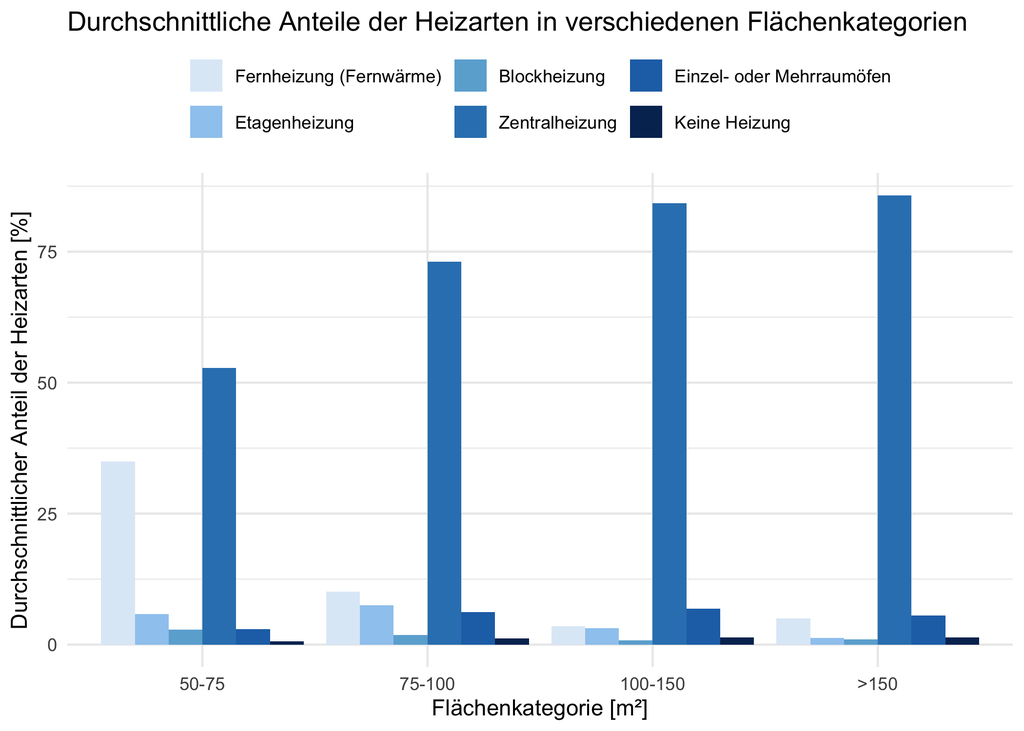

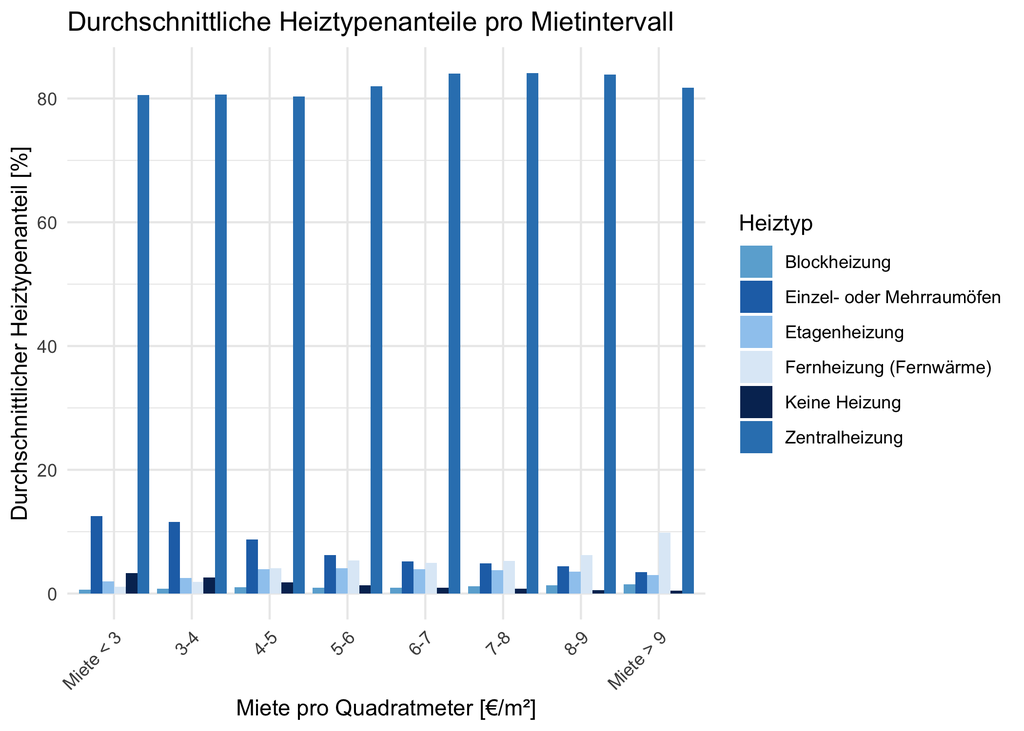

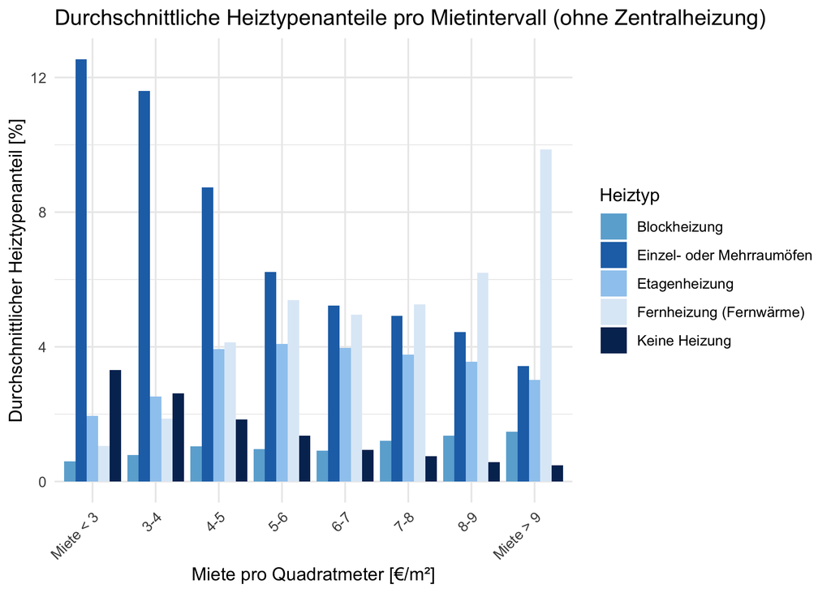

Der Zusammenhang zwischen Heizungsart und Wohnungsgröße zeigt deutliche Unterschiede in der Verteilung der Heizsysteme. Zentralheizungen sind zwar die am häufigsten verwendete Heizungsart in Deutschland, doch bei kleineren Wohnungen (unter 75 m²) werden oft Fernheizungen eingesetzt. Dies liegt daran, dass Fernwärme in städtischen Gebieten mit gut ausgebauten Netzen besonders verfügbar ist und für kleinere Wohnflächen eine effiziente Wärmeversorgung bietet. Mittelgroße Wohnungen weisen häufiger einen höheren Anteil an Raumöfen auf, die eine individuellere Steuerung ermöglichen. In größeren Wohnungen (über 75 m²) bleibt die Zentralheizung dominant, da sie für die Beheizung größerer Flächen effizienter und kostengünstiger ist.

Die Gründe für die Wahl bestimmter Heizsysteme lassen sich auf mehrere Faktoren zurückführen:

Gebäudetyp und Bauweise In großen Mehrfamilienhäusern oder Wohnanlagen sind zentrale Heizsysteme wie Fernwärme oder Zentralheizungen oft effizienter, da sie Energie für viele Wohnungen bereitstellen. In kleinen Gebäuden oder weniger gut isolierten Bauten sind dagegen Einzelöfen oder Nachtspeicherheizungen verbreitet, die eine gezielte Beheizung einzelner Räume ermöglichen.

Energieversorgung und regionale Unterschiede Die Verfügbarkeit von Fernwärme ist in urbanen Gebieten höher, während ländliche Regionen auf individuellere Heizsysteme wie Etagenheizungen oder Einzelöfen angewiesen sind. Regionale Energiequellen, wie Holz in Gebirgsgemeinden, beeinflussen ebenfalls die Heizungswahl.

Mietpreise und Heizsysteme Energieeffiziente Heizsysteme wie Fernwärme oder moderne Blockheizungen tragen durch geringere Betriebskosten zur Attraktivität höherpreisiger Wohnungen bei. Ältere Heizsysteme wie Raumöfen hingegen, die höhere Energiekosten verursachen, finden sich eher in günstigeren Mietwohnungen. Der Komfort und die Wahrnehmung von Qualität spielen ebenfalls eine Rolle: Moderne Heizsysteme gelten als umweltfreundlich und zukunftsfähig, was die Mietpreise steigen lässt.

Maßnahmen zur Begrenzung von Mietpreissteigerungen Um die Auswirkungen moderner Heizsysteme auf die Mietpreise zu begrenzen, könnte die Bundesregierung mehrere Strategien verfolgen:

Mietpreisobergrenzen: Begrenzung der Mietsteigerung nach Modernisierungen, sodass Vermieter nur einen Teil der Kosten für neue Heizsysteme auf die Mieter umlegen können. Subventionen für Vermieter: Zuschüsse oder steuerliche Anreize für energieeffiziente Heizsysteme könnten die Modernisierungskosten senken und Mietsteigerungen verhindern. Sozialwohnungen und Mietpreisbindung: Investitionen in Sozialwohnungen mit modernen Heizsystemen und die Einführung von Mietpreisbindungen für Neubauten könnten sicherstellen, dass energieeffiziente Heizsysteme auch in erschwinglichen Wohnungen verfügbar bleiben. Förderung von Mieterstrommodellen: Solche Modelle ermöglichen es Mietern, von gemeinschaftlichen Energiequellen zu profitieren, ohne dass die Mietpreise steigen. Diese Maßnahmen könnten dazu beitragen, den Übergang zu moderneren und nachhaltigeren Heizsystemen sozialverträglich zu gestalten und gleichzeitig die Wohnqualität zu verbessern.

Wie Sie in der Aufgabe 15 gesehen haben, haben Ulm und Stuttgart, sowie Dresden und Chemnitz ähnliche Verhältnisse bezüglich der Verteilung der Mietkosten über die Stadt hinweg. Aufgrund dessen beschränken Sie sich bei dieser Aufgabe auf die Städte Stuttgart und Dresden. Hier sollen Sie sich die einzelnen Heizungsarten über die Stadtteile hinweg anschauen, wie sich diese verteilen und ob hier Ähnlichkeiten zur Mietpreissstrukur vorliegt. Weiterhin sind vor allem die Heizungsarten Fernwärme, Zentralheizung und Etagenheizung in viele deutschen Wohnungen größtenteils verbaut, weshalb Sie gerade deswegen diese drei Heiztypen genauer beleuchten und untersuchen sollen.

19. Deshalb sollten Sie sich in einem ersten Schritt [diese Geogitter-Daten für die verschiedenen Heinzungsarten vom statistischen Bundesamt herunterladen](https://www.zensus2022.de/static/Zensus_Veroeffentlichung/Zensus2022_Heizungsart.zip). Speichern Sie die zip-Datei im Ordner `Daten` ab. Nutzen Sie erneut den Datensatz shape_file aus der Aufgabe 4 und joinen Sie die Informationen zu den Heizungsarten über die Variablen `x_mp_1km` und `y_mp_1km`.

In ihrem Datensatz können Sie sehen, dass es Einträge mit “-” gibt. Diese sollen sie für alle Heizungstypen durch 0 ersetzen. Achten Sie auch darauf, dass über alle Heizungstypen hinweg die Werte als numeric vorliegen.

Erstellen Sie nun für die Heizungsarten “Fernheizung”, “Etagenheizung” und “Zentralheizung” eine neue Spalte mit dem Anteil des jeweiligen Heizungstyps an allen Heizungen (`Insgesamt_Heizungsart`) je Gemeinde. Schließlich sollen Sie nun für die drei genannten Heizungsarten eine Karte erzeugen, welche den Anteil je Gitterebene im Stadtbezirk darstellt.

Beschreiben und interpretieren Sie ihre Grafiken. Berücksichtigen Sie dabei insbesondere folgende Fragen:

- Wo liegen Besonderheiten oder Muster in beiden Städten?
- Gibt es in Stuttgart und Dresden Stadtteile, bei denen bestimmte Heizungstypen in Einklang mit den Mietpreisen stehen, genauer gesagt, welche Heizungsarten korrelieren mit höheren oder niedrigeren Mietpreisen? Vergleichen Sie dazu die Ergebnisse aus Aufgabe 15.
- Was könnten Gründe sein, dass in bestimmten Stadtteilen vorwiegend eine bestimmte Form der Heizung eingebaut ist?
- Gibt es Unterschiede zwischen Ost- und Westdeutschland?
- Haben die Städte Stuttgart oder Dresden in den letzen Jahren Modernisierungen angestoßen oder Neuerungen umgesetzt und finanziell unterstützt, sodass es dort zu größeren Anpassungen bei der Heizungstechnik kam?

*Hinweis 1:* Sie sollen insgesamt für jede Stadt (Stuttgart und Dresden) drei verschiedene Karten erzeugen.

*Hinweis 2:* Achten Sie auf eine sinnvolle Einteilung und Darstellung in den Karten. Nutzen Sie die Karten aus vorherigen Aufgaben als Hilfestellung.

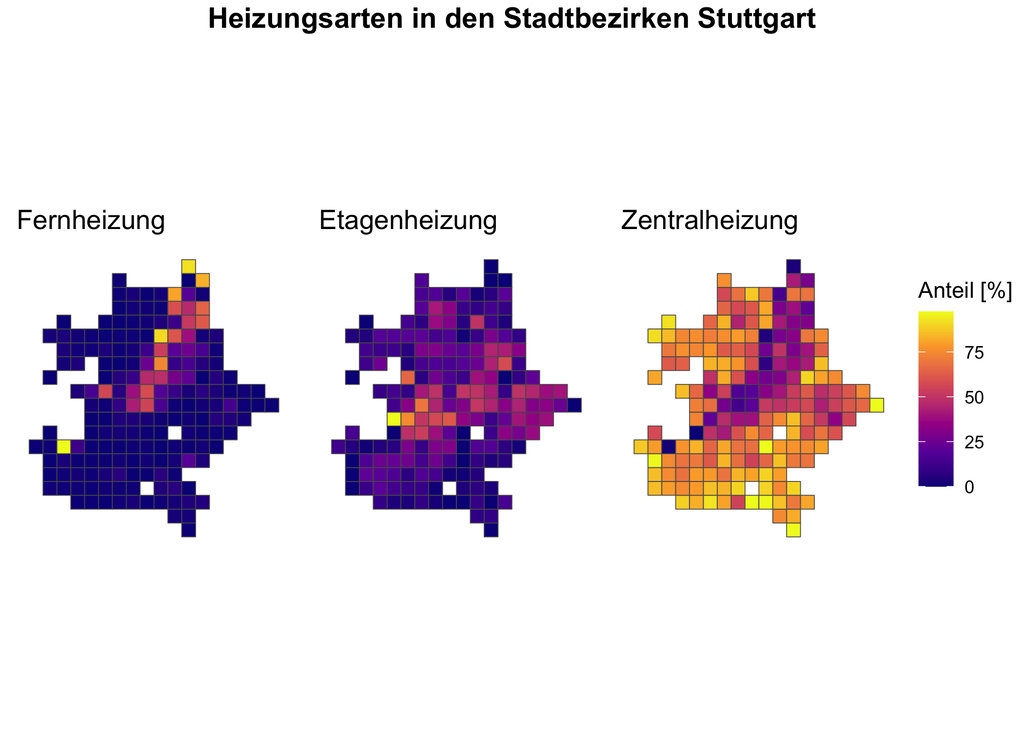

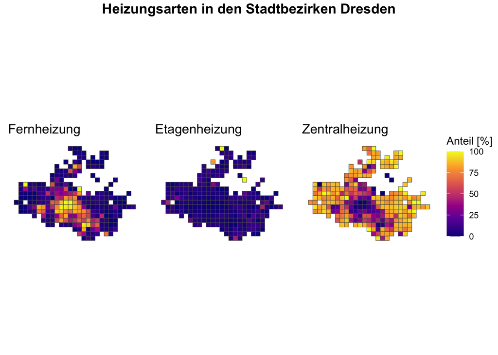

Beide Städte zeigen ein ähnliches Bild. In den meisten Stadtteilen ist die Zentralheizung dominierend. Auffällig ist, dass in beiden Städten jeweils im Zentrum die Verwendung der Zentralheizung deutlich geringer ist. Hier wird bei beiden Städten auf die Fernheizung zurückgegriffen. Der Anteil der Etagenheizung ist in beiden Städten gering. Jedoch ist er in Stuttgart höher als in Dresden. Im Gegensatz dazu ist der Anteil der Fernheizung in Dresden deutlich höher als in Stuttgart.

Vergleichen wir nun die Karten mit den Karten aus Aufgabe 15 so ist zu erkennen, dass in Dresden der Anteil der Fernheizung in den Stadtteilen hoch ist, in denen auch die durchschnittlichen Nettokaltmieten hoch sind. In Stuttgart hingegen ist der Anteil der Etagenheizung in den Stadtteilen hoch, in denen auch die durchschnittliche Nettokaltmiete sehr hoch ist.

Ein Grund für die unterschiedlichen Formen der Heiztypen könnte die Bauart und das Baujahr sein. Ältere Gebäude sind oft mit Etagenheizungen ausgestattet, während neuere Entwicklungen vermehrt auf Zentral- und Fernheizung setzen. Dies könnte dazu führen, dass Städte mit einer höheren Dichte an Neubauten tendenziell höhere Anteile an zentralen Heizsystemen aufweisen. Ein weiterer Grund könnte die Infrastruktur sein. Stadtteile mit gut entwickelter öffentlicher Infrastruktur und Versorgungsnetzwerken (z.B. Fernwärmeleitungen) sind eher geneigt, moderne Heizsysteme wie Fernheizungen zu installieren. Natürlich können aber auch wirtschaftliche Faktoren ein Grund sein. In wohlhabenderen Stadtteilen könnten höhere Investitionen in moderne Heizsysteme erfolgen, während in wirtschaftlich weniger stabilen Gebieten ältere Systeme vorherrschen, die günstiger in der Anschaffung sind.

Abschließend sollen Sie die Zusatzaufgabe noch einmal rekapitulieren und einige Fragen dazu beantworten.

20. Sie sollen sich noch einmal bewusst werden, was Sie in den vorherigen Aufgaben analysiert haben und in welcher Form ihre Ergebnisse anwendbar und verallgemeinbar sind. Beantworten Sie dazu Frage 1 und 2.

Frage 1: Betrachten Sie hierzu noch einmal exemplarisch die Städte Stuttgart und Dresden.

- Sind die Zusammenhänge zwischen Mietpreisen in den Städten und sozioökonomischer Faktoren vor allem auf Unterschiede zwischen den Städten oder auf Unterschiede innerhalb der Stadt zurückzuführen. Bei welchen Faktoren ist dies der Fall, wo nicht?
- Wie kann der Staat im Hinblick auf die unterschiedlichen Heizungsarten in den Städten eingreifen, um Wohnraum preiswerter zu gestalten?

Frage 2: Schauen Sie sich noch einmal die Verteilung der Heizungsarten (Fern-, Etagen- und Zentralheizungen) für Stuttgart und Dresden in Aufgabe 19 an. Betrachten Sie im Vergleich dazu ihre Grafik aus Aufgabe 8, sowie ihre Tabelle in Aufgabe 13?

- Was fällt Ihnen hier auf?
- Gibt es bestimmte Heizungstypen, die nur in alten oder neuen Wohnungen vorkommen?
- Welche Schlüsse würden Sie ziehen, die mit Handlungen der Politik einhergehen?

Frage 1 Die Mietpreise in Stuttgart und Dresden unterscheiden sich aufgrund verschiedener sozioökonomischer und struktureller Faktoren deutlich. Stuttgart ist eine wirtschaftlich starke Stadt, vor allem durch die Automobilindustrie mit Unternehmen wie Mercedes-Benz und Porsche sowie weiteren hochentwickelten Industrien. Diese wirtschaftliche Stärke führt zu höheren Einkommen und einer stärkeren Nachfrage nach Wohnraum, was die Mietpreise in Stuttgart deutlich erhöht. Im Vergleich dazu ist Dresden zwar eine bedeutende Stadt, aber wirtschaftlich nicht so dominant. Dies spiegelt sich in moderateren Mietpreisen wider.

Ein weiterer wichtiger Faktor ist das durchschnittliche Einkommen, das in Stuttgart höher ist als in Dresden. Dadurch können die Menschen in Stuttgart tendenziell mehr für Miete ausgeben, was wiederum zu höheren Preisen führt. Auch der Arbeitsmarkt spielt eine entscheidende Rolle: Stuttgart bietet zahlreiche hochbezahlte Arbeitsplätze, was die Zahlungsbereitschaft für höhere Mieten erhöht, während Dresden weniger Industrien mit vergleichbaren Lohnniveaus aufweist. Zusätzlich ist der Immobilienmarkt in Stuttgart durch eine hohe Nachfrage und ein begrenztes Angebot angespannt, was die Mietpreise weiter in die Höhe treibt. In Dresden ist das Wohnraumangebot größer, was den Preisanstieg dort etwas abmildert.

Innerhalb der Städte zeigen sich ebenfalls deutliche Unterschiede bei den Mietpreisen, die vor allem durch die soziale und wirtschaftliche Struktur der Stadtteile geprägt sind. In Stuttgart sind wohlhabende Stadtteile wie Degerloch oder Killesberg, die durch hohe Lebensqualität und gute Anbindung überzeugen, deutlich teurer. Dagegen sind Stadtteile wie Bad Cannstatt oder Zuffenhausen weniger zentral oder weniger begehrt, was sich in niedrigeren Mietpreisen zeigt. Diese Unterschiede resultieren aus der Nachfrage nach Wohnraum, die stark von Faktoren wie Einkommen, Bildung und Lebensstil abhängt.

Auch in Dresden sind ähnliche Muster erkennbar. In wohlhabenderen Stadtteilen wie Striesen oder Weißer Hirsch sind die Mietpreise höher, da diese Stadtteile eine hohe Lebensqualität bieten und entsprechend gefragt sind. Stadtteile wie Pieschen oder Prohlis, die oft weniger gehobene soziale Strukturen aufweisen, haben dagegen niedrigere Mietpreise. Wie in Stuttgart spiegeln diese Unterschiede die soziale Struktur und die Nachfrage nach Wohnungen in den verschiedenen Stadtteilen wider.

Zusammenfassend lassen sich die Unterschiede in den Mietpreisen zwischen Stuttgart und Dresden vor allem auf die wirtschaftlichen Rahmenbedingungen, das Einkommensniveau und die Industriestruktur zurückführen. Stuttgart ist eine wohlhabendere, wirtschaftlich stärkere Stadt, was zu höheren Mietpreisen führt. Gleichzeitig zeigen auch die innerstädtischen Unterschiede in beiden Städten, dass wohlhabendere Stadtteile deutlich höhere Mietpreise aufweisen, während weniger bevorzugte Gebiete günstigere Wohnmöglichkeiten bieten.

Frage 2

Der Vergleich der Daten aus den Aufgaben 13 und 19 zeigt, dass Bezirke mit höheren Mietpreisen tendenziell auch einen höheren Anteil an Etagenheizungen aufweisen. Dies könnte darauf hindeuten, dass in diesen teureren Bezirken möglicherweise ältere Gebäude dominieren, die noch mit Etagenheizungen ausgestattet sind. Alternativ könnte es auch darauf hinweisen, dass diese Bezirke eine vielfältige Bebauungsstruktur aufweisen, in der höhere Mieten modernere oder besser ausgestattete Etagenheizungen einschließen.

Etagenheizungen sind typischerweise in älteren Gebäuden zu finden, was die Beobachtung stützt, dass Bezirke mit höheren Mieten oft mehr Etagenheizungen aufweisen. Solche älteren Gebäude wurden häufig nicht auf moderne Heizsysteme umgerüstet, da die Installation von Zentralheizungen oft teuer und technisch aufwändig ist. Daher bleiben Etagenheizungen in vielen Fällen erhalten, insbesondere in Vierteln mit älteren Bauten, die durch ihre zentrale Lage oder ihre historischen Merkmale hohe Mietpreise erzielen können.

Auf Basis dieser Beobachtungen könnten mehrere politische Maßnahmen ergriffen werden, um die Energieeffizienz zu steigern und die Wohnqualität zu verbessern. Ein erster Ansatz wäre die Förderung von Modernisierungsprogrammen für Gebäude mit Etagenheizungen. Solche Programme könnten darauf abzielen, ältere Heizsysteme durch energieeffizientere Lösungen zu ersetzen, was nicht nur die Umwelt schont, sondern auch die Lebensqualität der Bewohner verbessert.

Zusätzlich könnten soziale Wohnungsbauprogramme gestärkt werden, um sicherzustellen, dass auch in teureren Bezirken bezahlbarer Wohnraum erhalten bleibt. Solche Maßnahmen könnten helfen, die Mietpreise zu stabilisieren und eine ausgewogene soziale Struktur in den betroffenen Gebieten zu gewährleisten.

Ein weiterer wichtiger Schritt wäre die Förderung von Energieberatungsdiensten, um Bewohner über die Vorteile und Möglichkeiten verschiedener Heizsysteme zu informieren. Eine umfassende Aufklärung könnte dabei helfen, individuelle Lösungen für energieeffizientes Wohnen zu finden und die Akzeptanz moderner Heiztechnologien zu erhöhen.

Diese politischen Maßnahmen könnten einen wichtigen Beitrag dazu leisten, die energetische Ausstattung von Wohngebieten zu verbessern, soziale Ungleichheiten zu mindern und gleichzeitig den Übergang zu umweltfreundlicheren Heizsystemen zu beschleunigen.